# London Average Air Quality Index Analysis

## Eshita Goel

### LSE ID 202102193

### Candidate Number 34611

### ST445 - Managing and Visualising Data (Final Project)

[figure not shown]

Image Source : London Air

## Contents

- Notebook Intructions
- Interactive Plots
- Libraries Used
- Commented Cells
- Images
- Aim
- Data Used
- Nature of Data
- Data Description
- Data Acquisition
- Reading from CSV Files
- Reading from Excel Files
- Web Scraping
- Data Cleaning
- Data Visualisation
- Data Modelling
- Conclusion and Results

## Notebook Instructions

### Interactive Plots

Plots made using libraries like Plotly, and any geographical visualizations (like the ones made using Folium) are not visible in the Jupyter Notebook when viewed on Github. These, however, are visible in the HTML file version of the project. **Animated plots** are also included in this project that can be viewed in the HTML version of the document.

### Libraries Used

Some libraries used in this project, such as Folium, need to be installed before they work. The commands to install them are below:  
**Folium**  
`!pip -q install folium`  
**Plotly**  
`!pip install plotly`  
**Cufflinks**  
`!pip install cufflinks`  
**Geopandas**  
`!pip install geopandas`

### Commented Cells

Some cells in this notebook take a significant amount of time to execute. This can break the flow of the execution and can take up hours. I have commented out such cells (and provided an alternative) or put comments above cells where the execution time is longer than normal.

### Images

The Notebook has a few cells that are used to display images, these images are stored in the **"images"** folder (uploaded in the project repository). When executing this file on a local machine, the image folder can be kept in the same working directory as the project for the corresponding cells to work. Otherwise the cells can be commented out.

## Aim

Through this project, we wish to analyse the trends in the **Average Air Quality Index** of London between January 2008 and July 2019.

**The study will explore the following the points :-**

- The various pollutants in the air that are monitored to calculate the Air Quality Index
- Comparison between "Roadside" and "Background" Monitors
- Amount of pollutants in the air at different times of the day, month, and year
- The emissions of the various pollutants from the London Boroughs

**We also try to answer the following questions :-**

- How does the Air Quality Index vary over a period of 10 years ?
- Trends in Air Quality Index depending on the time of the day, month and year ?
- Which London Boroughs have the most emissions for the pollutants?
- Can we group the Boroughs based on their level of pollutant emissions?

## Data Used

We make use of datasets available online from known sources (csv or xls files), along with scraping data wherever required. All sources can be found below for reference :-

### Nature of Data

Data

Source

Nature of Data

[**London Average Air Quality Levels**](https://data.london.gov.uk/dataset/london-average-air-quality-levels)

King's College London (London Datastore)

- CSV File with AQI Monthly Averages
- CSV File with AQI at different times of the day

[**What is the Daily Air Quality Index?**](https://uk-air.defra.gov.uk/air-pollution/daqi?view=more-info&pollutant=pm10)

Department for Environment Food & Rural Affairs

Web Page

[**London Atmospheric Emissions (LAEI) 2016**](https://data.london.gov.uk/dataset/london-atmospheric-emissions-inventory--laei--2016)

GLA and TFL Air Quality (London Datastore)

Excel File

[**List of London boroughs**](https://en.wikipedia.org/wiki/List_of_London_boroughs)

Wikipedia

Web Page

[**Guide for Monitoring Air Quality London (Jan 2018)**](https://www.london.gov.uk/sites/default/files/air_quality_monitoring_guidance_january_2018.pdf)

London.gov.uk

PDF File for reference

[**Statistical GIS Boundary Files for London**](https://data.london.gov.uk/dataset/statistical-gis-boundary-files-london)

Greater London Authority (GLA) (London Datastore)

We only use the Shape File

### Data Description

**London Average Air Quality Levels**

This dataset includes 2 CSV Files. The first file contains information about the 5 major pollutants in the air during each month between 2008 and 2019. The second file contains the levels of the pollutants at different times of the day for each month between 2008 and 2019. Both files have data collected from 2 types of monitors (Roadside and Background)

**What is the Daily Air Quality Index? (Web Page)**

This webpage contains a table that has up-to-date information about the level of pollutant in the air that makes the air pollution Low, Moderate, High, or Very High

**London Atmospheric Emissions (LAEI) 2016**

This Excel file contains informtion about how much pollutant was emitted from each London Borough in 2016. For our analysis, we are only interested in the total emission of various pollutants, and not on the causes for these emissions.

**List of London boroughs**

The Wikipedia Web Page containing list of all London Boroughs. We can use this web page to extract information about the population, latitude, longitude and area or each borough.

**Guide for Monitoring Air Quality London (Jan 2018)**

This document helps us understand the difference between the two kinds of monitors (Roadside and Background) used to collect information about the various pollutants. It also gives us details about how the Air Pollution in London is measured. This is only used for reference purposes.

**Statistical GIS Boundary Files for London**

The Shape File in this dataset helps us to plot maps of London Boroughs using the Geopandas Library. This allows us to visualise multiple fatures in a graphical manner.

## Data Acquisition

We are dealing with multiple data sources for this project. We acquire the data in the following ways:-

- **CSV and Excel Files** : These can be loaded directly using the Pandas library. We get a dataframe which we can further work with
- **Web Pages** : We can scrap the relevent data using the Beautiful Soup Library
- **PDF Files and External References** : Since these are only needed for refernce, we do not need to load the data into our Jupyter Notebook. Any relevant information can be quoted in markdown cells.

```python
# Importing all libraries

import pandas as pd
import numpy as np
import requests
from bs4 import BeautifulSoup
import folium
import geopandas as gpd

from sklearn.cluster import KMeans
from sklearn.preprocessing import StandardScaler
from sklearn.metrics import silhouette_score

import chart_studio.plotly as py
import cufflinks as cf
import seaborn as sns
import plotly.express as px
import plotly.graph_objects as go
from plotly.subplots import make_subplots
import matplotlib.pyplot as plt
import matplotlib.cm as cm
import matplotlib.colors as colors
%matplotlib inline

# Make Plotly work in the Jupyter Notebook
from plotly.offline import download_plotlyjs, init_notebook_mode, plot, iplot
init_notebook_mode(connected=True)

# Use Plotly locally
cf.go_offline()
```

### Reading from CSV Files

```python
# London Average Air Quality Levels (csv File)

AQI_month = pd.read_csv("data/air-quality-london-monthly-averages.csv")
AQI_day   = pd.read_csv("data/air-quality-london-time-of-day.csv")
```

```python
display(AQI_month.head())
print("AQI_month has dimensions : ",AQI_month.shape)
```

|  | Month | London Mean Roadside:Nitric Oxide (ug/m3) | London Mean Roadside:Nitrogen Dioxide (ug/m3) | London Mean Roadside:Oxides of Nitrogen (ug/m3) | London Mean Roadside:Ozone (ug/m3) | London Mean Roadside:PM10 Particulate (ug/m3) | London Mean Roadside:PM2.5 Particulate (ug/m3) | London Mean Roadside:Sulphur Dioxide (ug/m3) | London Mean Background:Nitric Oxide (ug/m3) | London Mean Background:Nitrogen Dioxide (ug/m3) | London Mean Background:Oxides of Nitrogen (ug/m3) | London Mean Background:Ozone (ug/m3) | London Mean Background:PM10 Particulate (ug/m3) | London Mean Background:PM2.5 Particulate (ug/m3) | London Mean Background:Sulphur Dioxide (ug/m3) |
| --- | --- | --- | --- | --- | --- | --- | --- | --- | --- | --- | --- | --- | --- | --- | --- |
| 0 | Jan-08 | NaN | 55.5 | NaN | 29.5 | 25.0 | 14.7 | 4.2 | NaN | 42.3 | NaN | 36.9 | 18.8 | . | 3.6 |
| 1 | Feb-08 | NaN | 75.9 | NaN | 20.3 | 39.5 | 28.8 | 7.6 | NaN | 60.2 | NaN | 26.4 | 31.9 | . | 6.7 |
| 2 | Mar-08 | NaN | 55.6 | NaN | 40.1 | 21.6 | 12.3 | 3.9 | NaN | 39.8 | NaN | 50.2 | 15.5 | . | 2.3 |
| 3 | Apr-08 | NaN | 61.8 | NaN | 37.9 | 28.7 | 20.5 | 4.5 | NaN | 44.0 | NaN | 50.1 | 21.7 | . | 3.2 |
| 4 | May-08 | NaN | 62.9 | NaN | 46.3 | 34.6 | 27.5 | 4.6 | NaN | 44.1 | NaN | 60.5 | 29.5 | 16.6 | 4.3 |

```
AQI_month has dimensions :  (139, 15)
```

```python
display(AQI_day.head())
print("AQI_day has dimensions : ",AQI_day.shape)
```

|  | Month (text) | GMT | London Mean Roadside:Nitric Oxide (ug/m3) | London Mean Roadside:Nitrogen Dioxide (ug/m3) | London Mean Roadside:Oxides of Nitrogen (ug/m3) | London Mean Roadside:Ozone (ug/m3) | London Mean Roadside:PM10 Particulate (ug/m3) | London Mean Roadside:PM2.5 Particulate (ug/m3) | London Mean Roadside:Sulphur Dioxide (ug/m3) | London Mean Background:Nitric Oxide (ug/m3) | London Mean Background:Nitrogen Dioxide (ug/m3) | London Mean Background:Oxides of Nitrogen (ug/m3) | London Mean Background:Ozone (ug/m3) | London Mean Background:PM10 Particulate (ug/m3) | London Mean Background:PM2.5 Particulate (ug/m3) | London Mean Background:Sulphur Dioxide (ug/m3) |
| --- | --- | --- | --- | --- | --- | --- | --- | --- | --- | --- | --- | --- | --- | --- | --- | --- |
| 0 | Jan-08 | 00:00 | NaN | 42.3 | NaN | 32.6 | 23.0 | 15.5 | 3.4 | NaN | 34.2 | NaN | 41.8 | 19.2 | . | 3.1 |
| 1 | Jan-08 | 01:00 | NaN | 33.8 | NaN | 35.3 | 21.2 | 13.5 | 2.6 | NaN | 29.0 | NaN | 45.3 | 18.9 | . | 3.1 |
| 2 | Jan-08 | 02:00 | NaN | 28.8 | NaN | 43.2 | 19.6 | 12.7 | 2.1 | NaN | 25.4 | NaN | 46.6 | 17.7 | . | 3.3 |
| 3 | Jan-08 | 03:00 | NaN | 27.3 | NaN | 42.4 | 18.3 | 11.9 | 2.0 | NaN | 23.4 | NaN | 46.6 | 16.4 | . | 3.3 |
| 4 | Jan-08 | 04:00 | NaN | 29.4 | NaN | 40.1 | 18.1 | 12.0 | 2.2 | NaN | 24.2 | NaN | 45.2 | 16.0 | . | 2.8 |

```
AQI_day has dimensions :  (3336, 16)
```

To get the **Boundaries Between Index Points for Each Pollutant**, we can scrap data from [this](https://uk-air.defra.gov.uk/air-pollution/daqi?view=more-info) webpage.  
We need values for each pollutant (Ozone, Nitrogen Dioxide, Sulphur Dioxide, PM2.5 Particles, and PM10 Particles). This can be done by visiting their subsequent webpages and scraping the table that contains these boundary values.

## *Note*

The following code is put in comments because the Department for Environment Food & Rural Affairs website often doesnt give permission to scrap the data, a lot of attempts made result in the **403 Forbidden** Error that says that " *You don't have permission to access /air-pollution/daqi on this server.* "  
So instead of using this code to get the Boundaries Between Index Points, we can use the table provided by London Datastore. This is in an Excel file and can thus be easily read by Pandas.

```python
# The following code visits the webpages for each pollutant on the Department for Environment Food & Rural Affairs
# website and scraps the table that includes the Boundaries Between Index Points for that pollutant

'''
pollutants = ["ozone","no2","so2","pm25","pm10"]

df = {}

for pollutant in pollutants:
    url = "https://uk-air.defra.gov.uk/air-pollution/daqi?view=more-info&pollutant={}#pollutant".format(pollutant)
    page = requests.get(url)
    soup = BeautifulSoup(page.content,"lxml")
    table = soup.find_all('table')[0]
    df0 = pd.read_html(str(table))[0]
    df[pollutant] = df0
df
'''
```

```
'\npollutants = ["ozone","no2","so2","pm25","pm10"]\n\ndf = {}\n\nfor pollutant in pollutants:\n    url = "https://uk-air.defra.gov.uk/air-pollution/daqi?view=more-info&pollutant={}#pollutant".format(pollutant)\n    page = requests.get(url)\n    soup = BeautifulSoup(page.content,"lxml")\n    table =…
```

### Reading from Excel Files

```python
air_excel = pd.read_excel("data/air-quality-london.xlsx", sheet_name = "AQ Index bands & Sources", header = 2)
```

```python
display(air_excel.head())
```

|  | Band | Index | Nitrogen dioxide \n1-hour mean \n(µg m–3) | Unnamed: 3 | Ozone \n8-hourly mean \n(µg m–3) | Unnamed: 5 | PM10 particles \n24-hour mean \n(µg m–3) | Unnamed: 7 | PM2.5 particles \n24-hour mean \n(µg m–3) | Unnamed: 9 | Sulphur dioxide \n15 minute mean \n(µg m–3) | Unnamed: 11 | Unnamed: 12 | Health Advice to Accompany the Air Quality Index | Unnamed: 14 |
| --- | --- | --- | --- | --- | --- | --- | --- | --- | --- | --- | --- | --- | --- | --- | --- |
| 0 | NaN | NaN | Min | Max | Min | Max | Min | Max | Min | Max | Min | Max | NaN | At-risk individuals* | General population |
| 1 | Low | 1.0 | 0 | 67.499 | 0 | 33.499 | 0 | 16.499 | 0 | 11.499 | 0 | 88.499 | NaN | Enjoy your usual outdoor activities | Enjoy your usual outdoor activities |
| 2 | NaN | 2.0 | 67.5 | 134.499 | 33.5 | 66.499 | 16.5 | 33.499 | 11.5 | 23.499 | 88.5 | 177.499 | NaN | NaN | NaN |
| 3 | NaN | 3.0 | 134.5 | 200.499 | 66.5 | 100.499 | 33.5 | 50.499 | 23.5 | 35.499 | 177.5 | 266.499 | NaN | NaN | NaN |
| 4 | Moderate | 4.0 | 200.5 | 267.499 | 100.5 | 120.499 | 50.5 | 58.499 | 35.5 | 41.499 | 266.5 | 354.499 | NaN | Adults and children with lung problems, and ad... | Enjoy your usual outdoor activities |

We have the above dataframe with the boundary values for each pollutant. This Data Frame needs considerable amount of cleaning, which we will do in the data cleaning section.

### London Atmospheric Emissions (LAEI) 2016

We need this dataset to get information about how much pollution was emitted from each London Borough in 2016.  
This excel file contains a separate sheet for each pollutant, which in turn has a table containing the borough names, the causes of emission, and the total emission value.  
For our project, we are not interested in the casues of the emissions, and are only concerned with the final emission value of each pollutant.  
**Note:** This dataset has values for only 4 polluants (Nitrogen Dioxide, Carbon Dioxide, PM2.5 particles and PM10 Particles). The data for Ozone and Sulphur Dioxide is not present.  
From inspecting the data, we can see that the data for Carbon Dioxide has missing values for multiple boroughs, and thus, has missing values of the final emssions of CO2 in multiple boroughs. Therefore, we do not use this data.  
We focus on our 3 main pollutants that have complete data present (Nitrogen Dioxide, PM2.5 particles and PM10 Particles)

```python
## Loading data into separate dataframes - **** THIS CELL TAKES LONGER THAN NORMAL TO EXECUTE ****

pollutants = {"NOx", "PM2.5","PM10"}

df_list = {} # storing the dataframes in a dictionary

for pollutant in pollutants:
    df = pd.read_excel("data/LAEI2016_Emissions_Summary-NOxPMCO2.xlsx", sheet_name = "{} Summary".format(pollutant))
    df_list[pollutant] = df
```

**df_list** contains the dataframes for each of the three pollutants. We will have to extract the total emissions values for each borough from these dataframes, which we will handle during data cleaning.

### Information about Boroughs from Wikipedia

We get details about each London Borough from Wikipedia

### Web Scraping

```python
url = "https://en.wikipedia.org/wiki/List_of_London_boroughs"
page = requests.get(url)
soup = BeautifulSoup(page.content,"lxml")
table = soup.find_all('table')[0]
boroughs = pd.read_html(str(table))[0]
boroughs.head()
```

|  | Borough | Inner | Status | Local authority | Political control | Headquarters | Area (sq mi) | Population (2019 est)[1] | Co-ordinates | Nr. in map |
| --- | --- | --- | --- | --- | --- | --- | --- | --- | --- | --- |
| 0 | Barking and Dagenham[note 1] | NaN | NaN | Barking and Dagenham London Borough Council | Labour | Town Hall, 1 Town Square | 13.93 | 212906 | .mw-parser-output .geo-default,.mw-parser-outp... | 25 |
| 1 | Barnet | NaN | NaN | Barnet London Borough Council | Conservative | Barnet House, 2 Bristol Avenue, Colindale | 33.49 | 395896 | 51°37′31″N 0°09′06″W / 51.6252°N 0.1517°W | 31 |
| 2 | Bexley | NaN | NaN | Bexley London Borough Council | Conservative | Civic Offices, 2 Watling Street | 23.38 | 248287 | 51°27′18″N 0°09′02″E / 51.4549°N 0.1505°E | 23 |
| 3 | Brent | NaN | NaN | Brent London Borough Council | Labour | Brent Civic Centre, Engineers Way | 16.70 | 329771 | 51°33′32″N 0°16′54″W / 51.5588°N 0.2817°W | 12 |
| 4 | Bromley | NaN | NaN | Bromley London Borough Council | Conservative | Civic Centre, Stockwell Close | 57.97 | 332336 | 51°24′14″N 0°01′11″E / 51.4039°N 0.0198°E | 20 |

## Data Cleaning

We now clean all the data extracted so that we can efficiently use it for Data Visualization.

```python
AQI_month.head(3)
```

|  | Month | London Mean Roadside:Nitric Oxide (ug/m3) | London Mean Roadside:Nitrogen Dioxide (ug/m3) | London Mean Roadside:Oxides of Nitrogen (ug/m3) | London Mean Roadside:Ozone (ug/m3) | London Mean Roadside:PM10 Particulate (ug/m3) | London Mean Roadside:PM2.5 Particulate (ug/m3) | London Mean Roadside:Sulphur Dioxide (ug/m3) | London Mean Background:Nitric Oxide (ug/m3) | London Mean Background:Nitrogen Dioxide (ug/m3) | London Mean Background:Oxides of Nitrogen (ug/m3) | London Mean Background:Ozone (ug/m3) | London Mean Background:PM10 Particulate (ug/m3) | London Mean Background:PM2.5 Particulate (ug/m3) | London Mean Background:Sulphur Dioxide (ug/m3) |
| --- | --- | --- | --- | --- | --- | --- | --- | --- | --- | --- | --- | --- | --- | --- | --- |
| 0 | Jan-08 | NaN | 55.5 | NaN | 29.5 | 25.0 | 14.7 | 4.2 | NaN | 42.3 | NaN | 36.9 | 18.8 | . | 3.6 |
| 1 | Feb-08 | NaN | 75.9 | NaN | 20.3 | 39.5 | 28.8 | 7.6 | NaN | 60.2 | NaN | 26.4 | 31.9 | . | 6.7 |
| 2 | Mar-08 | NaN | 55.6 | NaN | 40.1 | 21.6 | 12.3 | 3.9 | NaN | 39.8 | NaN | 50.2 | 15.5 | . | 2.3 |

```python
AQI_month.info()
```

```
<class 'pandas.core.frame.DataFrame'>
RangeIndex: 139 entries, 0 to 138
Data columns (total 15 columns):
 #   Column                                             Non-Null Count  Dtype
---  ------                                             --------------  -----
 0   Month                                              139 non-null    object
 1   London Mean Roadside:Nitric Oxide (ug/m3)          115 non-null    float64
 2   London Mean Roadside:Nitrogen Dioxide (ug/m3)      139 non-null    float64
 3   London Mean Roadside:Oxides of Nitrogen (ug/m3)    115 non-null    float64
 4   London Mean Roadside:Ozone (ug/m3)                 139 non-null    float64
 5   London Mean Roadside:PM10 Particulate (ug/m3)      139 non-null    float64
 6   London Mean Roadside:PM2.5 Particulate (ug/m3)     139 non-null    float64
 7   London Mean Roadside:Sulphur Dioxide (ug/m3)       139 non-null    float64
 8   London Mean Background:Nitric Oxide (ug/m3)        115 non-null    float64
 9   London Mean Background:Nitrogen Dioxide (ug/m3)    139 non-null    float64
 10  London Mean Background:Oxides of Nitrogen (ug/m3)  115 non-null    float64
 11  London Mean Background:Ozone (ug/m3)               139 non-null    float64
 12  London Mean Background:PM10 Particulate (ug/m3)    139 non-null    float64
 13  London Mean Background:PM2.5 Particulate (ug/m3)   139 non-null    object
 14  London Mean Background:Sulphur Dioxide (ug/m3)     139 non-null    float64
dtypes: float64(13), object(2)
memory usage: 16.4+ KB
```

**We perform the following tasks on this dataset:**

1. Separate the Month and Year, so that we can use them individually for analysis
2. Rename the columns so that they are easier to understand
3. The Background PM2.5 column is an object, when it should be numeric, we will have to fix this
4. Check for Missing values and handle them in an efficient way

```python
# We first separate the month and year in the dataframe

months = []
years = []

for date in AQI_month['Month'].values:
    month = date.split('-')[0]
    year = date.split('-')[1]
    months.append(month)
    years.append('20'+ year)

AQI_month['Month'] = months
AQI_month['Year'] = years
```

```python
display(AQI_month[['Month','Year']].head(5))
display(AQI_month[['Month','Year']].tail(5))
```

|  | Month | Year |
| --- | --- | --- |
| 0 | Jan | 2008 |
| 1 | Feb | 2008 |
| 2 | Mar | 2008 |
| 3 | Apr | 2008 |
| 4 | May | 2008 |

[output not shown]

```python
AQI_month.rename(columns = {'London Mean Roadside:Nitric Oxide (ug/m3)':'Roadside NO',
                            'London Mean Roadside:Nitrogen Dioxide (ug/m3)':'Roadside NO2',
                           'London Mean Roadside:Oxides of Nitrogen (ug/m3)':'Roadside Nitrogen Oxides',
                           'London Mean Roadside:Ozone (ug/m3)':'Roadside Ozone',
                           'London Mean Roadside:PM10 Particulate (ug/m3)':'Roadside PM10',
                           'London Mean Roadside:PM2.5 Particulate (ug/m3)':'Roadside PM2.5',
                           'London Mean Roadside:Sulphur Dioxide (ug/m3)':'Roadside SO2',
                           'London Mean Background:Nitric Oxide (ug/m3)':'BG NO',
                           'London Mean Background:Nitrogen Dioxide (ug/m3)':'BG NO2',
                           'London Mean Background:Oxides of Nitrogen (ug/m3)':'BG Nitrogen Oxides',
                           'London Mean Background:Ozone (ug/m3)':'BG Ozone',
                           'London Mean Background:PM10 Particulate (ug/m3)':'BG PM10',
                           'London Mean Background:PM2.5 Particulate (ug/m3)':'BG PM2.5',
                           'London Mean Background:Sulphur Dioxide (ug/m3)':'BG SO2'},inplace = True)
AQI_month.head(3)
```

|  | Month | Roadside NO | Roadside NO2 | Roadside Nitrogen Oxides | Roadside Ozone | Roadside PM10 | Roadside PM2.5 | Roadside SO2 | BG NO | BG NO2 | BG Nitrogen Oxides | BG Ozone | BG PM10 | BG PM2.5 | BG SO2 | Year |
| --- | --- | --- | --- | --- | --- | --- | --- | --- | --- | --- | --- | --- | --- | --- | --- | --- |
| 0 | Jan | NaN | 55.5 | NaN | 29.5 | 25.0 | 14.7 | 4.2 | NaN | 42.3 | NaN | 36.9 | 18.8 | . | 3.6 | 2008 |
| 1 | Feb | NaN | 75.9 | NaN | 20.3 | 39.5 | 28.8 | 7.6 | NaN | 60.2 | NaN | 26.4 | 31.9 | . | 6.7 | 2008 |
| 2 | Mar | NaN | 55.6 | NaN | 40.1 | 21.6 | 12.3 | 3.9 | NaN | 39.8 | NaN | 50.2 | 15.5 | . | 2.3 | 2008 |

```python
# Checking for NULL values

AQI_month.isnull().sum()
```

```
Month                        0
Roadside NO                 24
Roadside NO2                 0
Roadside Nitrogen Oxides    24
Roadside Ozone               0
Roadside PM10                0
Roadside PM2.5               0
Roadside SO2                 0
BG NO                       24
BG NO2                       0
BG Nitrogen Oxides          24
BG Ozone                     0
BG PM10                      0
BG PM2.5                     0
BG SO2                       0
Year                         0
dtype: int64
```

We want to know exactly where the missing values occur

```python
missing = ['Roadside NO','Roadside Nitrogen Oxides','BG NO','BG Nitrogen Oxides']

for value in missing:
    print("For ",value)
    print(AQI_month['Year'][AQI_month[value].isnull()].unique())
    print(AQI_month['Month'][AQI_month[value].isnull()].unique(),'\n')
```

```
For  Roadside NO
['2008' '2009']
['Jan' 'Feb' 'Mar' 'Apr' 'May' 'Jun' 'Jul' 'Aug' 'Sep' 'Oct' 'Nov' 'Dec']

For  Roadside Nitrogen Oxides
['2008' '2009']
['Jan' 'Feb' 'Mar' 'Apr' 'May' 'Jun' 'Jul' 'Aug' 'Sep' 'Oct' 'Nov' 'Dec']

For  BG NO
['2008' '2009']
['Jan' 'Feb' 'Mar' 'Apr' 'May' 'Jun' 'Jul' 'Aug' 'Sep' 'Oct' 'Nov' 'Dec']

For  BG Nitrogen Oxides
['2008' '2009']
['Jan' 'Feb' 'Mar' 'Apr' 'May' 'Jun' 'Jul' 'Aug' 'Sep' 'Oct' 'Nov' 'Dec']
```

This means that the 24 missing values in the columns are for the two years 2008 and 2009.  
Since all the values for these columns in these two years are missing, we can drop these and focus our analysis on the other values.

```python
AQI_month.dropna(inplace=True)

AQI_month.isnull().sum()
```

```
Month                       0
Roadside NO                 0
Roadside NO2                0
Roadside Nitrogen Oxides    0
Roadside Ozone              0
Roadside PM10               0
Roadside PM2.5              0
Roadside SO2                0
BG NO                       0
BG NO2                      0
BG Nitrogen Oxides          0
BG Ozone                    0
BG PM10                     0
BG PM2.5                    0
BG SO2                      0
Year                        0
dtype: int64
```

```python
AQI_month.reset_index(inplace=True,drop=True)
AQI_month
```

[output not shown]

115 rows × 16 columns

```python
AQI_month.info()
```

```
<class 'pandas.core.frame.DataFrame'>
RangeIndex: 115 entries, 0 to 114
Data columns (total 16 columns):
 #   Column                    Non-Null Count  Dtype
---  ------                    --------------  -----
 0   Month                     115 non-null    object
 1   Roadside NO               115 non-null    float64
 2   Roadside NO2              115 non-null    float64
 3   Roadside Nitrogen Oxides  115 non-null    float64
 4   Roadside Ozone            115 non-null    float64
 5   Roadside PM10             115 non-null    float64
 6   Roadside PM2.5            115 non-null    float64
 7   Roadside SO2              115 non-null    float64
 8   BG NO                     115 non-null    float64
 9   BG NO2                    115 non-null    float64
 10  BG Nitrogen Oxides        115 non-null    float64
 11  BG Ozone                  115 non-null    float64
 12  BG PM10                   115 non-null    float64
 13  BG PM2.5                  115 non-null    object
 14  BG SO2                    115 non-null    float64
 15  Year                      115 non-null    object
dtypes: float64(13), object(3)
memory usage: 14.5+ KB
```

**BG PM2.5** is still an object, we convert it to float

```python
AQI_month['BG PM2.5'] = pd.to_numeric(AQI_month['BG PM2.5'])
AQI_month.info()
```

```
<class 'pandas.core.frame.DataFrame'>
RangeIndex: 115 entries, 0 to 114
Data columns (total 16 columns):
 #   Column                    Non-Null Count  Dtype
---  ------                    --------------  -----
 0   Month                     115 non-null    object
 1   Roadside NO               115 non-null    float64
 2   Roadside NO2              115 non-null    float64
 3   Roadside Nitrogen Oxides  115 non-null    float64
 4   Roadside Ozone            115 non-null    float64
 5   Roadside PM10             115 non-null    float64
 6   Roadside PM2.5            115 non-null    float64
 7   Roadside SO2              115 non-null    float64
 8   BG NO                     115 non-null    float64
 9   BG NO2                    115 non-null    float64
 10  BG Nitrogen Oxides        115 non-null    float64
 11  BG Ozone                  115 non-null    float64
 12  BG PM10                   115 non-null    float64
 13  BG PM2.5                  115 non-null    float64
 14  BG SO2                    115 non-null    float64
 15  Year                      115 non-null    object
dtypes: float64(14), object(2)
memory usage: 14.5+ KB
```

Now our **AQI_month** is clean!

### AQI_day

```python
AQI_day.head(3)
```

|  | Month (text) | GMT | London Mean Roadside:Nitric Oxide (ug/m3) | London Mean Roadside:Nitrogen Dioxide (ug/m3) | London Mean Roadside:Oxides of Nitrogen (ug/m3) | London Mean Roadside:Ozone (ug/m3) | London Mean Roadside:PM10 Particulate (ug/m3) | London Mean Roadside:PM2.5 Particulate (ug/m3) | London Mean Roadside:Sulphur Dioxide (ug/m3) | London Mean Background:Nitric Oxide (ug/m3) | London Mean Background:Nitrogen Dioxide (ug/m3) | London Mean Background:Oxides of Nitrogen (ug/m3) | London Mean Background:Ozone (ug/m3) | London Mean Background:PM10 Particulate (ug/m3) | London Mean Background:PM2.5 Particulate (ug/m3) | London Mean Background:Sulphur Dioxide (ug/m3) |
| --- | --- | --- | --- | --- | --- | --- | --- | --- | --- | --- | --- | --- | --- | --- | --- | --- |
| 0 | Jan-08 | 00:00 | NaN | 42.3 | NaN | 32.6 | 23.0 | 15.5 | 3.4 | NaN | 34.2 | NaN | 41.8 | 19.2 | . | 3.1 |
| 1 | Jan-08 | 01:00 | NaN | 33.8 | NaN | 35.3 | 21.2 | 13.5 | 2.6 | NaN | 29.0 | NaN | 45.3 | 18.9 | . | 3.1 |
| 2 | Jan-08 | 02:00 | NaN | 28.8 | NaN | 43.2 | 19.6 | 12.7 | 2.1 | NaN | 25.4 | NaN | 46.6 | 17.7 | . | 3.3 |

```python
AQI_day.info()
```

```
<class 'pandas.core.frame.DataFrame'>
RangeIndex: 3336 entries, 0 to 3335
Data columns (total 16 columns):
 #   Column                                             Non-Null Count  Dtype
---  ------                                             --------------  -----
 0   Month (text)                                       3336 non-null   object
 1   GMT                                                3336 non-null   object
 2   London Mean Roadside:Nitric Oxide (ug/m3)          2760 non-null   float64
 3   London Mean Roadside:Nitrogen Dioxide (ug/m3)      3336 non-null   float64
 4   London Mean Roadside:Oxides of Nitrogen (ug/m3)    2760 non-null   float64
 5   London Mean Roadside:Ozone (ug/m3)                 3336 non-null   float64
 6   London Mean Roadside:PM10 Particulate (ug/m3)      3336 non-null   float64
 7   London Mean Roadside:PM2.5 Particulate (ug/m3)     3336 non-null   float64
 8   London Mean Roadside:Sulphur Dioxide (ug/m3)       3336 non-null   float64
 9   London Mean Background:Nitric Oxide (ug/m3)        2760 non-null   float64
 10  London Mean Background:Nitrogen Dioxide (ug/m3)    3336 non-null   float64
 11  London Mean Background:Oxides of Nitrogen (ug/m3)  2760 non-null   float64
 12  London Mean Background:Ozone (ug/m3)               3336 non-null   float64
 13  London Mean Background:PM10 Particulate (ug/m3)    3336 non-null   float64
 14  London Mean Background:PM2.5 Particulate (ug/m3)   3336 non-null   object
 15  London Mean Background:Sulphur Dioxide (ug/m3)     3336 non-null   float64
dtypes: float64(13), object(3)
memory usage: 417.1+ KB
```

**We perform the following tasks on this dataset:**

1. Separate the **Month** and **Year**, so that we can use them individually for analysis
2. Rename the columns to make them easy to understand
3. The Background PM2.5 column is an object, when it should be numeric, we will have to fix this
4. Check for Missing values and handle them in an efficient way

```python
# We first separate the month and year in the dataframe

months = []
years = []

for date in AQI_day['Month (text)'].values:
    month = date.split('-')[0]
    year = date.split('-')[1]
    months.append(month)
    years.append('20'+ year)

AQI_day['Month'] = months
AQI_day['Year'] = years
```

```python
# we can drop the original Months column now
AQI_day.drop(columns = 'Month (text)', inplace = True)
```

```python
display(AQI_day.head(3))
display(AQI_day.tail(3))
```

|  | GMT | London Mean Roadside:Nitric Oxide (ug/m3) | London Mean Roadside:Nitrogen Dioxide (ug/m3) | London Mean Roadside:Oxides of Nitrogen (ug/m3) | London Mean Roadside:Ozone (ug/m3) | London Mean Roadside:PM10 Particulate (ug/m3) | London Mean Roadside:PM2.5 Particulate (ug/m3) | London Mean Roadside:Sulphur Dioxide (ug/m3) | London Mean Background:Nitric Oxide (ug/m3) | London Mean Background:Nitrogen Dioxide (ug/m3) | London Mean Background:Oxides of Nitrogen (ug/m3) | London Mean Background:Ozone (ug/m3) | London Mean Background:PM10 Particulate (ug/m3) | London Mean Background:PM2.5 Particulate (ug/m3) | London Mean Background:Sulphur Dioxide (ug/m3) | Month | Year |
| --- | --- | --- | --- | --- | --- | --- | --- | --- | --- | --- | --- | --- | --- | --- | --- | --- | --- |
| 0 | 00:00 | NaN | 42.3 | NaN | 32.6 | 23.0 | 15.5 | 3.4 | NaN | 34.2 | NaN | 41.8 | 19.2 | . | 3.1 | Jan | 2008 |
| 1 | 01:00 | NaN | 33.8 | NaN | 35.3 | 21.2 | 13.5 | 2.6 | NaN | 29.0 | NaN | 45.3 | 18.9 | . | 3.1 | Jan | 2008 |
| 2 | 02:00 | NaN | 28.8 | NaN | 43.2 | 19.6 | 12.7 | 2.1 | NaN | 25.4 | NaN | 46.6 | 17.7 | . | 3.3 | Jan | 2008 |

|  | GMT | London Mean Roadside:Nitric Oxide (ug/m3) | London Mean Roadside:Nitrogen Dioxide (ug/m3) | London Mean Roadside:Oxides of Nitrogen (ug/m3) | London Mean Roadside:Ozone (ug/m3) | London Mean Roadside:PM10 Particulate (ug/m3) | London Mean Roadside:PM2.5 Particulate (ug/m3) | London Mean Roadside:Sulphur Dioxide (ug/m3) | London Mean Background:Nitric Oxide (ug/m3) | London Mean Background:Nitrogen Dioxide (ug/m3) | London Mean Background:Oxides of Nitrogen (ug/m3) | London Mean Background:Ozone (ug/m3) | London Mean Background:PM10 Particulate (ug/m3) | London Mean Background:PM2.5 Particulate (ug/m3) | London Mean Background:Sulphur Dioxide (ug/m3) | Month | Year |
| --- | --- | --- | --- | --- | --- | --- | --- | --- | --- | --- | --- | --- | --- | --- | --- | --- | --- |
| 3333 | 21:00 | 18.2 | 39.4 | 67.3 | 29.4 | 18.5 | 10.7 | 5.8 | 3.2 | 23.0 | 26.2 | 50.4 | 14.2 | 9.5 | 2.5 | Jul | 2019 |
| 3334 | 22:00 | 16.0 | 37.5 | 62.0 | 28.4 | 18.0 | 9.6 | 5.7 | 3.1 | 22.5 | 25.7 | 46.7 | 14.5 | 9.4 | 2.5 | Jul | 2019 |
| 3335 | 23:00 | 13.1 | 34.2 | 54.3 | 27.6 | 16.7 | 9.2 | 5.6 | 2.6 | 21.2 | 24.2 | 45.0 | 14.4 | 9.2 | 2.4 | Jul | 2019 |

```python
AQI_day.rename(columns = {'London Mean Roadside:Nitric Oxide (ug/m3)':'Roadside NO',
                            'London Mean Roadside:Nitrogen Dioxide (ug/m3)':'Roadside NO2',
                           'London Mean Roadside:Oxides of Nitrogen (ug/m3)':'Roadside Nitrogen Oxides',
                           'London Mean Roadside:Ozone (ug/m3)':'Roadside Ozone',
                           'London Mean Roadside:PM10 Particulate (ug/m3)':'Roadside PM10',
                           'London Mean Roadside:PM2.5 Particulate (ug/m3)':'Roadside PM2.5',
                           'London Mean Roadside:Sulphur Dioxide (ug/m3)':'Roadside SO2',
                           'London Mean Background:Nitric Oxide (ug/m3)':'BG NO',
                           'London Mean Background:Nitrogen Dioxide (ug/m3)':'BG NO2',
                           'London Mean Background:Oxides of Nitrogen (ug/m3)':'BG Nitrogen Oxides',
                           'London Mean Background:Ozone (ug/m3)':'BG Ozone',
                           'London Mean Background:PM10 Particulate (ug/m3)':'BG PM10',
                           'London Mean Background:PM2.5 Particulate (ug/m3)':'BG PM2.5',
                           'London Mean Background:Sulphur Dioxide (ug/m3)':'BG SO2',
                         'GMT':'Time'},inplace = True)
```

```python
AQI_day.head(2)
```

|  | Time | Roadside NO | Roadside NO2 | Roadside Nitrogen Oxides | Roadside Ozone | Roadside PM10 | Roadside PM2.5 | Roadside SO2 | BG NO | BG NO2 | BG Nitrogen Oxides | BG Ozone | BG PM10 | BG PM2.5 | BG SO2 | Month | Year |
| --- | --- | --- | --- | --- | --- | --- | --- | --- | --- | --- | --- | --- | --- | --- | --- | --- | --- |
| 0 | 00:00 | NaN | 42.3 | NaN | 32.6 | 23.0 | 15.5 | 3.4 | NaN | 34.2 | NaN | 41.8 | 19.2 | . | 3.1 | Jan | 2008 |
| 1 | 01:00 | NaN | 33.8 | NaN | 35.3 | 21.2 | 13.5 | 2.6 | NaN | 29.0 | NaN | 45.3 | 18.9 | . | 3.1 | Jan | 2008 |

```python
 # Checking for NULL values

AQI_day.isnull().sum()
```

```
Time                          0
Roadside NO                 576
Roadside NO2                  0
Roadside Nitrogen Oxides    576
Roadside Ozone                0
Roadside PM10                 0
Roadside PM2.5                0
Roadside SO2                  0
BG NO                       576
BG NO2                        0
BG Nitrogen Oxides          576
BG Ozone                      0
BG PM10                       0
BG PM2.5                      0
BG SO2                        0
Month                         0
Year                          0
dtype: int64
```

We want to know exactly where the missing values occur

```python
missing = ['Roadside NO','Roadside Nitrogen Oxides','BG NO','BG Nitrogen Oxides']

for value in missing:
    print("For ",value)
    print(AQI_day['Year'][AQI_day[value].isnull()].unique())
    print(AQI_day['Month'][AQI_day[value].isnull()].unique(),'\n')
```

```
For  Roadside NO
['2008' '2009']
['Jan' 'Feb' 'Mar' 'Apr' 'May' 'Jun' 'Jul' 'Aug' 'Sep' 'Oct' 'Nov' 'Dec']

For  Roadside Nitrogen Oxides
['2008' '2009']
['Jan' 'Feb' 'Mar' 'Apr' 'May' 'Jun' 'Jul' 'Aug' 'Sep' 'Oct' 'Nov' 'Dec']

For  BG NO
['2008' '2009']
['Jan' 'Feb' 'Mar' 'Apr' 'May' 'Jun' 'Jul' 'Aug' 'Sep' 'Oct' 'Nov' 'Dec']

For  BG Nitrogen Oxides
['2008' '2009']
['Jan' 'Feb' 'Mar' 'Apr' 'May' 'Jun' 'Jul' 'Aug' 'Sep' 'Oct' 'Nov' 'Dec']
```

Again, for this data as well, the missing values are only for the two years (2008 and 2009). We can drop these values and focus our analysis on the remaining years

```python
AQI_day.dropna(inplace=True)

AQI_day.isnull().sum()
```

```
Time                        0
Roadside NO                 0
Roadside NO2                0
Roadside Nitrogen Oxides    0
Roadside Ozone              0
Roadside PM10               0
Roadside PM2.5              0
Roadside SO2                0
BG NO                       0
BG NO2                      0
BG Nitrogen Oxides          0
BG Ozone                    0
BG PM10                     0
BG PM2.5                    0
BG SO2                      0
Month                       0
Year                        0
dtype: int64
```

```python
AQI_day.reset_index(inplace=True,drop=True)
```

```python
AQI_day.head(3)
```

|  | Time | Roadside NO | Roadside NO2 | Roadside Nitrogen Oxides | Roadside Ozone | Roadside PM10 | Roadside PM2.5 | Roadside SO2 | BG NO | BG NO2 | BG Nitrogen Oxides | BG Ozone | BG PM10 | BG PM2.5 | BG SO2 | Month | Year |
| --- | --- | --- | --- | --- | --- | --- | --- | --- | --- | --- | --- | --- | --- | --- | --- | --- | --- |
| 0 | 00:00 | 63.9 | 54.8 | 118.8 | 15.3 | 27.4 | 23.5 | 4.0 | 32.4 | 46.4 | 78.9 | 18.0 | 24.6 | 22.1 | 3.7 | Jan | 2010 |
| 1 | 01:00 | 51.7 | 48.6 | 100.4 | 17.3 | 25.7 | 22.6 | 3.6 | 29.4 | 42.8 | 72.2 | 20.2 | 23.4 | 21.4 | 3.6 | Jan | 2010 |
| 2 | 02:00 | 44.0 | 43.3 | 87.4 | 19.7 | 24.5 | 20.9 | 3.3 | 25.0 | 39.4 | 64.5 | 21.6 | 22.5 | 20.6 | 3.0 | Jan | 2010 |

```python
AQI_day['BG PM2.5'] = pd.to_numeric(AQI_day['BG PM2.5'])
AQI_day.info()
```

```
<class 'pandas.core.frame.DataFrame'>
RangeIndex: 2760 entries, 0 to 2759
Data columns (total 17 columns):
 #   Column                    Non-Null Count  Dtype
---  ------                    --------------  -----
 0   Time                      2760 non-null   object
 1   Roadside NO               2760 non-null   float64
 2   Roadside NO2              2760 non-null   float64
 3   Roadside Nitrogen Oxides  2760 non-null   float64
 4   Roadside Ozone            2760 non-null   float64
 5   Roadside PM10             2760 non-null   float64
 6   Roadside PM2.5            2760 non-null   float64
 7   Roadside SO2              2760 non-null   float64
 8   BG NO                     2760 non-null   float64
 9   BG NO2                    2760 non-null   float64
 10  BG Nitrogen Oxides        2760 non-null   float64
 11  BG Ozone                  2760 non-null   float64
 12  BG PM10                   2760 non-null   float64
 13  BG PM2.5                  2760 non-null   float64
 14  BG SO2                    2760 non-null   float64
 15  Month                     2760 non-null   object
 16  Year                      2760 non-null   object
dtypes: float64(14), object(3)
memory usage: 366.7+ KB
```

Now our **AQI_day** is clean!

### Cleaning air_excel

```python
air_excel.head(11)
```

|  | Band | Index | Nitrogen dioxide \n1-hour mean \n(µg m–3) | Unnamed: 3 | Ozone \n8-hourly mean \n(µg m–3) | Unnamed: 5 | PM10 particles \n24-hour mean \n(µg m–3) | Unnamed: 7 | PM2.5 particles \n24-hour mean \n(µg m–3) | Unnamed: 9 | Sulphur dioxide \n15 minute mean \n(µg m–3) | Unnamed: 11 | Unnamed: 12 | Health Advice to Accompany the Air Quality Index | Unnamed: 14 |
| --- | --- | --- | --- | --- | --- | --- | --- | --- | --- | --- | --- | --- | --- | --- | --- |
| 0 | NaN | NaN | Min | Max | Min | Max | Min | Max | Min | Max | Min | Max | NaN | At-risk individuals* | General population |
| 1 | Low | 1.0 | 0 | 67.499 | 0 | 33.499 | 0 | 16.499 | 0 | 11.499 | 0 | 88.499 | NaN | Enjoy your usual outdoor activities | Enjoy your usual outdoor activities |
| 2 | NaN | 2.0 | 67.5 | 134.499 | 33.5 | 66.499 | 16.5 | 33.499 | 11.5 | 23.499 | 88.5 | 177.499 | NaN | NaN | NaN |
| 3 | NaN | 3.0 | 134.5 | 200.499 | 66.5 | 100.499 | 33.5 | 50.499 | 23.5 | 35.499 | 177.5 | 266.499 | NaN | NaN | NaN |
| 4 | Moderate | 4.0 | 200.5 | 267.499 | 100.5 | 120.499 | 50.5 | 58.499 | 35.5 | 41.499 | 266.5 | 354.499 | NaN | Adults and children with lung problems, and ad... | Enjoy your usual outdoor activities |
| 5 | NaN | 5.0 | 267.5 | 334.499 | 120.5 | 140.499 | 58.5 | 66.499 | 41.5 | 47.499 | 354.5 | 443.499 | NaN | NaN | NaN |
| 6 | NaN | 6.0 | 334.5 | 400.499 | 140.5 | 160.499 | 66.5 | 75.499 | 47.5 | 53.499 | 443.5 | 532.499 | NaN | NaN | NaN |
| 7 | High | 7.0 | 400.5 | 467.499 | 160.5 | 187.499 | 75.5 | 83.499 | 53.5 | 58.499 | 532.5 | 710.499 | NaN | Adults and children with lung problems, and ad... | Anyone experiencing discomfort such as sore ey... |
| 8 | NaN | 8.0 | 467.5 | 534.499 | 187.5 | 213.499 | 83.5 | 91.499 | 58.5 | 64.499 | 710.5 | 887.499 | NaN | NaN | NaN |
| 9 | NaN | 9.0 | 534.5 | 600.499 | 213.5 | 240.499 | 91.5 | 100.499 | 64.5 | 70.499 | 887.5 | 1064.5 | NaN | NaN | NaN |
| 10 | Very High | 10.0 | 600.5 | NaN | 240.5 | NaN | 100.5 | NaN | 70.5 | NaN | 1064.5 | NaN | NaN | Adults and children with lung problems, adults... | Reduce physical exertion, particularly outdoor... |

#### Cleaning Points:

1. All irrelevant data loaded from the Excel file needs to be removed
2. The headers need to be fixed so that we can easily reference them
3. The Row containing the Band values ('Low','Moderate' etc.) has NaN values which need to be replaced
4. Some other cells have NaN values, which will need to be replaced

```python
# We first extract only the relevant part of the dataframe

boundaries = air_excel.iloc[1:11,:12]
boundaries
```

|  | Band | Index | Nitrogen dioxide \n1-hour mean \n(µg m–3) | Unnamed: 3 | Ozone \n8-hourly mean \n(µg m–3) | Unnamed: 5 | PM10 particles \n24-hour mean \n(µg m–3) | Unnamed: 7 | PM2.5 particles \n24-hour mean \n(µg m–3) | Unnamed: 9 | Sulphur dioxide \n15 minute mean \n(µg m–3) | Unnamed: 11 |
| --- | --- | --- | --- | --- | --- | --- | --- | --- | --- | --- | --- | --- |
| 1 | Low | 1.0 | 0 | 67.499 | 0 | 33.499 | 0 | 16.499 | 0 | 11.499 | 0 | 88.499 |
| 2 | NaN | 2.0 | 67.5 | 134.499 | 33.5 | 66.499 | 16.5 | 33.499 | 11.5 | 23.499 | 88.5 | 177.499 |
| 3 | NaN | 3.0 | 134.5 | 200.499 | 66.5 | 100.499 | 33.5 | 50.499 | 23.5 | 35.499 | 177.5 | 266.499 |
| 4 | Moderate | 4.0 | 200.5 | 267.499 | 100.5 | 120.499 | 50.5 | 58.499 | 35.5 | 41.499 | 266.5 | 354.499 |
| 5 | NaN | 5.0 | 267.5 | 334.499 | 120.5 | 140.499 | 58.5 | 66.499 | 41.5 | 47.499 | 354.5 | 443.499 |
| 6 | NaN | 6.0 | 334.5 | 400.499 | 140.5 | 160.499 | 66.5 | 75.499 | 47.5 | 53.499 | 443.5 | 532.499 |
| 7 | High | 7.0 | 400.5 | 467.499 | 160.5 | 187.499 | 75.5 | 83.499 | 53.5 | 58.499 | 532.5 | 710.499 |
| 8 | NaN | 8.0 | 467.5 | 534.499 | 187.5 | 213.499 | 83.5 | 91.499 | 58.5 | 64.499 | 710.5 | 887.499 |
| 9 | NaN | 9.0 | 534.5 | 600.499 | 213.5 | 240.499 | 91.5 | 100.499 | 64.5 | 70.499 | 887.5 | 1064.5 |
| 10 | Very High | 10.0 | 600.5 | NaN | 240.5 | NaN | 100.5 | NaN | 70.5 | NaN | 1064.5 | NaN |

```python
rows = ['Low','Low','Low','Moderate','Moderate','Moderate','High','High','High','Very High']
```

```python
boundaries.rename(columns = {'Nitrogen dioxide \n1-hour mean \n(µg m–3)':'NO2_min',
                            'Unnamed: 3':'NO2_max','Ozone \n8-hourly mean \n(µg m–3)':'Ozone_min',
                            'Unnamed: 5':'Ozone_max','PM10 particles \n24-hour mean \n(µg m–3)':'PM10_min',
                            'Unnamed: 7':'PM10_max','PM2.5 particles \n24-hour mean \n(µg m–3)':'PM2.5_min',
                            'Unnamed: 9':'PM2.5_max','Sulphur dioxide \n15 minute mean \n(µg m–3)':'SO2_min',
                            'Unnamed: 11':'SO2_max'},inplace=True)
boundaries['Band'] = rows
boundaries
```

|  | Band | Index | Nitrogen dioxide \n1-hour mean \n(µg m–3) | NO2_max | Ozone \n8-hourly mean \n(µg m–3) | Ozone_max | PM10_min | PM10_max | PM2.5_min | PM2.5_max | Sulphur dioxide \n15 minute mean \n(µg m–3) | SO2_max |
| --- | --- | --- | --- | --- | --- | --- | --- | --- | --- | --- | --- | --- |
| 1 | Low | 1.0 | 0 | 67.499 | 0 | 33.499 | 0 | 16.499 | 0 | 11.499 | 0 | 88.499 |
| 2 | Low | 2.0 | 67.5 | 134.499 | 33.5 | 66.499 | 16.5 | 33.499 | 11.5 | 23.499 | 88.5 | 177.499 |
| 3 | Low | 3.0 | 134.5 | 200.499 | 66.5 | 100.499 | 33.5 | 50.499 | 23.5 | 35.499 | 177.5 | 266.499 |
| 4 | Moderate | 4.0 | 200.5 | 267.499 | 100.5 | 120.499 | 50.5 | 58.499 | 35.5 | 41.499 | 266.5 | 354.499 |
| 5 | Moderate | 5.0 | 267.5 | 334.499 | 120.5 | 140.499 | 58.5 | 66.499 | 41.5 | 47.499 | 354.5 | 443.499 |
| 6 | Moderate | 6.0 | 334.5 | 400.499 | 140.5 | 160.499 | 66.5 | 75.499 | 47.5 | 53.499 | 443.5 | 532.499 |
| 7 | High | 7.0 | 400.5 | 467.499 | 160.5 | 187.499 | 75.5 | 83.499 | 53.5 | 58.499 | 532.5 | 710.499 |
| 8 | High | 8.0 | 467.5 | 534.499 | 187.5 | 213.499 | 83.5 | 91.499 | 58.5 | 64.499 | 710.5 | 887.499 |
| 9 | High | 9.0 | 534.5 | 600.499 | 213.5 | 240.499 | 91.5 | 100.499 | 64.5 | 70.499 | 887.5 | 1064.5 |
| 10 | Very High | 10.0 | 600.5 | NaN | 240.5 | NaN | 100.5 | NaN | 70.5 | NaN | 1064.5 | NaN |

We observe that some columns are not renamed properly using this technique, this could be due to the presence of some special characters in the column names. We can retry the renaming using the column index instead.

```python
boundaries.rename(columns= {boundaries.columns[2]:'NO2_min',
                           boundaries.columns[4]:'Ozone_min',
                           boundaries.columns[10]:'SO2_min'},inplace=True)
boundaries
```

|  | Band | Index | NO2_min | NO2_max | Ozone_min | Ozone_max | PM10_min | PM10_max | PM2.5_min | PM2.5_max | SO2_min | SO2_max |
| --- | --- | --- | --- | --- | --- | --- | --- | --- | --- | --- | --- | --- |
| 1 | Low | 1.0 | 0 | 67.499 | 0 | 33.499 | 0 | 16.499 | 0 | 11.499 | 0 | 88.499 |
| 2 | Low | 2.0 | 67.5 | 134.499 | 33.5 | 66.499 | 16.5 | 33.499 | 11.5 | 23.499 | 88.5 | 177.499 |
| 3 | Low | 3.0 | 134.5 | 200.499 | 66.5 | 100.499 | 33.5 | 50.499 | 23.5 | 35.499 | 177.5 | 266.499 |
| 4 | Moderate | 4.0 | 200.5 | 267.499 | 100.5 | 120.499 | 50.5 | 58.499 | 35.5 | 41.499 | 266.5 | 354.499 |
| 5 | Moderate | 5.0 | 267.5 | 334.499 | 120.5 | 140.499 | 58.5 | 66.499 | 41.5 | 47.499 | 354.5 | 443.499 |
| 6 | Moderate | 6.0 | 334.5 | 400.499 | 140.5 | 160.499 | 66.5 | 75.499 | 47.5 | 53.499 | 443.5 | 532.499 |
| 7 | High | 7.0 | 400.5 | 467.499 | 160.5 | 187.499 | 75.5 | 83.499 | 53.5 | 58.499 | 532.5 | 710.499 |
| 8 | High | 8.0 | 467.5 | 534.499 | 187.5 | 213.499 | 83.5 | 91.499 | 58.5 | 64.499 | 710.5 | 887.499 |
| 9 | High | 9.0 | 534.5 | 600.499 | 213.5 | 240.499 | 91.5 | 100.499 | 64.5 | 70.499 | 887.5 | 1064.5 |
| 10 | Very High | 10.0 | 600.5 | NaN | 240.5 | NaN | 100.5 | NaN | 70.5 | NaN | 1064.5 | NaN |

```python
boundaries.isnull().sum()
```

```
Band         0
Index        0
NO2_min      0
NO2_max      1
Ozone_min    0
Ozone_max    1
PM10_min     0
PM10_max     1
PM2.5_min    0
PM2.5_max    1
SO2_min      0
SO2_max      1
dtype: int64
```

The **Band** value **Very High** has a few NaN values. These represent that there is no upper bound to the pollutant's concentration in the air. We can replace these values with a very high number that represents a very high value (something that will not happen in real life).

```python
boundaries.fillna(10000,inplace=True)
boundaries[boundaries['Band']=='Very High']
```

|  | Band | Index | NO2_min | NO2_max | Ozone_min | Ozone_max | PM10_min | PM10_max | PM2.5_min | PM2.5_max | SO2_min | SO2_max |
| --- | --- | --- | --- | --- | --- | --- | --- | --- | --- | --- | --- | --- |
| 10 | Very High | 10.0 | 600.5 | 10000.0 | 240.5 | 10000.0 | 100.5 | 10000.0 | 70.5 | 10000.0 | 1064.5 | 10000.0 |

```python
boundaries.isnull().sum()
```

```
Band         0
Index        0
NO2_min      0
NO2_max      0
Ozone_min    0
Ozone_max    0
PM10_min     0
PM10_max     0
PM2.5_min    0
PM2.5_max    0
SO2_min      0
SO2_max      0
dtype: int64
```

We now have a clean dataframe - **boundaries**.

### Cleaning the Information about the Air Pollution in Boroughs

```python
# The pollutants whose data we have

df_list.keys()
```

```
dict_keys(['PM10', 'NOx', 'PM2.5'])
```

#### Cleaning Points

- We first create 3 different dataframes for the 3 pollutants 'NOx', 'PM2.5', and 'PM10'
- We then slice the dataframe so that we only have information about the boroughs and the total pollutant emission

We examine the excel file manually to see where exactly the required data is present so that we can slice the dataframes.  
Each excel sheet has 2 tables, the second table is the one that contains the information relevant to us. This table begins from the 11th column in the excel sheet.

```python
display(df_list['NOx'].iloc[6:,11:].head(3))
display(df_list['NOx'].iloc[6:,11:].tail(3))
```

|  | Unnamed: 11 | Unnamed: 12 | Unnamed: 13 | Unnamed: 14 | Unnamed: 15 | Unnamed: 16 | Unnamed: 17 | Unnamed: 18 | Unnamed: 19 | Unnamed: 20 | ... | Unnamed: 36 | Unnamed: 37 | Unnamed: 38 | Unnamed: 39 | Unnamed: 40 | Unnamed: 41 | Unnamed: 42 | Unnamed: 43 | Unnamed: 44 | Unnamed: 45 |
| --- | --- | --- | --- | --- | --- | --- | --- | --- | --- | --- | --- | --- | --- | --- | --- | --- | --- | --- | --- | --- | --- |
| 6 | Source | Barking and Dagenham | Barnet | Bexley | Brent | Bromley | Camden | City | City of Westminster | Croydon | ... | Merton | Newham | Redbridge | Richmond | Southwark | Sutton | Tower Hamlets | Waltham Forest | Wandsworth | Non GLA |
| 7 | Domestic | 51.8545 | 141.903 | 82.1423 | 98.7942 | 148.901 | 57.9886 | 0.926835 | 64.8381 | 151.529 | ... | 72.9013 | 69.9064 | 96.0571 | 86.9172 | 71.3049 | 73.8928 | 41.2686 | 74.4078 | 97.7918 | 429.94 |
| 8 | Biomass | NaN | NaN | NaN | NaN | NaN | NaN | NaN | NaN | NaN | ... | NaN | NaN | NaN | NaN | NaN | NaN | NaN | NaN | NaN | NaN |

3 rows × 35 columns

|  | Unnamed: 11 | Unnamed: 12 | Unnamed: 13 | Unnamed: 14 | Unnamed: 15 | Unnamed: 16 | Unnamed: 17 | Unnamed: 18 | Unnamed: 19 | Unnamed: 20 | ... | Unnamed: 36 | Unnamed: 37 | Unnamed: 38 | Unnamed: 39 | Unnamed: 40 | Unnamed: 41 | Unnamed: 42 | Unnamed: 43 | Unnamed: 44 | Unnamed: 45 |
| --- | --- | --- | --- | --- | --- | --- | --- | --- | --- | --- | --- | --- | --- | --- | --- | --- | --- | --- | --- | --- | --- |
| 67 | TfL Bus | 56.3836 | 135.758 | 63.888 | 117.585 | 87.777 | 110.008 | 50.5223 | 199.766 | 109.309 | ... | 53.572 | 121.114 | 77.1766 | 76.3549 | 111.285 | 36.879 | 75.4128 | 77.3393 | 85.7995 | 82.9308 |
| 68 | LAEI (Grand Total) | 909.442 | 1831.89 | 2238.08 | 1419.35 | 1285.05 | 1136.53 | 577.401 | 2052.01 | 1199.58 | ... | 644.048 | 1468.12 | 1024.82 | 978.025 | 1057.15 | 678.487 | 1184.97 | 812.008 | 955.17 | 11493.7 |
| 69 | NaN | NaN | NaN | NaN | NaN | NaN | NaN | NaN | NaN | NaN | ... | NaN | NaN | NaN | NaN | NaN | NaN | NaN | NaN | NaN | NaN |

3 rows × 35 columns

```python
# Getting just the relevant information
air_boroughs = df_list['NOx'].iloc[[6,68],12:]
air_boroughs
```

|  | Unnamed: 12 | Unnamed: 13 | Unnamed: 14 | Unnamed: 15 | Unnamed: 16 | Unnamed: 17 | Unnamed: 18 | Unnamed: 19 | Unnamed: 20 | Unnamed: 21 | ... | Unnamed: 36 | Unnamed: 37 | Unnamed: 38 | Unnamed: 39 | Unnamed: 40 | Unnamed: 41 | Unnamed: 42 | Unnamed: 43 | Unnamed: 44 | Unnamed: 45 |
| --- | --- | --- | --- | --- | --- | --- | --- | --- | --- | --- | --- | --- | --- | --- | --- | --- | --- | --- | --- | --- | --- |
| 6 | Barking and Dagenham | Barnet | Bexley | Brent | Bromley | Camden | City | City of Westminster | Croydon | Ealing | ... | Merton | Newham | Redbridge | Richmond | Southwark | Sutton | Tower Hamlets | Waltham Forest | Wandsworth | Non GLA |
| 68 | 909.442 | 1831.89 | 2238.08 | 1419.35 | 1285.05 | 1136.53 | 577.401 | 2052.01 | 1199.58 | 1631.56 | ... | 644.048 | 1468.12 | 1024.82 | 978.025 | 1057.15 | 678.487 | 1184.97 | 812.008 | 955.17 | 11493.7 |

2 rows × 34 columns

```python
# Renaming columns
air_boroughs.columns = air_boroughs.iloc[0]
```

```python
# We now make a dataframe with just the borough names and the NOx emissions as columns
air_boroughs = air_boroughs.iloc[1,:]
air_boroughs.reset_index(drop=True)
air_boroughs = pd.DataFrame(air_boroughs)
air_boroughs.reset_index(inplace=True)
air_boroughs.rename(columns = {6:'Borough',68:'NOx'}, inplace = True)
air_boroughs.head()
```

|  | Borough | NOx |
| --- | --- | --- |
| 0 | Barking and Dagenham | 909.442 |
| 1 | Barnet | 1831.89 |
| 2 | Bexley | 2238.08 |
| 3 | Brent | 1419.35 |
| 4 | Bromley | 1285.05 |

We can now append this dataframe with the **PM10** and **PM2.5** values for each borough

```python
df_PM25 = df_list['PM2.5'].iloc[[6,68],12:]
df_PM10 = df_list['PM10'].iloc[[6,68],12:]

display(df_PM25)
display(df_PM10)
```

|  | Unnamed: 12 | Unnamed: 13 | Unnamed: 14 | Unnamed: 15 | Unnamed: 16 | Unnamed: 17 | Unnamed: 18 | Unnamed: 19 | Unnamed: 20 | Unnamed: 21 | ... | Unnamed: 36 | Unnamed: 37 | Unnamed: 38 | Unnamed: 39 | Unnamed: 40 | Unnamed: 41 | Unnamed: 42 | Unnamed: 43 | Unnamed: 44 | Unnamed: 45 |
| --- | --- | --- | --- | --- | --- | --- | --- | --- | --- | --- | --- | --- | --- | --- | --- | --- | --- | --- | --- | --- | --- |
| 6 | Barking and Dagenham | Barnet | Bexley | Brent | Bromley | Camden | City | City of Westminster | Croydon | Ealing | ... | Merton | Newham | Redbridge | Richmond | Southwark | Sutton | Tower Hamlets | Waltham Forest | Wandsworth | Non GLA |
| 68 | 104.478 | 188.619 | 143.658 | 117.783 | 160.323 | 101.132 | 45.2054 | 203.479 | 138.685 | 161.664 | ... | 78.7775 | 131.399 | 108.085 | 86.8901 | 89.3078 | 84.2083 | 113.404 | 86.1213 | 103.371 | 855.399 |

2 rows × 34 columns

|  | Unnamed: 12 | Unnamed: 13 | Unnamed: 14 | Unnamed: 15 | Unnamed: 16 | Unnamed: 17 | Unnamed: 18 | Unnamed: 19 | Unnamed: 20 | Unnamed: 21 | ... | Unnamed: 36 | Unnamed: 37 | Unnamed: 38 | Unnamed: 39 | Unnamed: 40 | Unnamed: 41 | Unnamed: 42 | Unnamed: 43 | Unnamed: 44 | Unnamed: 45 |
| --- | --- | --- | --- | --- | --- | --- | --- | --- | --- | --- | --- | --- | --- | --- | --- | --- | --- | --- | --- | --- | --- |
| 6 | Barking and Dagenham | Barnet | Bexley | Brent | Bromley | Camden | City | City of Westminster | Croydon | Ealing | ... | Merton | Newham | Redbridge | Richmond | Southwark | Sutton | Tower Hamlets | Waltham Forest | Wandsworth | Non GLA |
| 68 | 235.321 | 469.191 | 304.201 | 241.791 | 361.063 | 178.14 | 71.3615 | 346.852 | 289.546 | 333.356 | ... | 149.015 | 289.607 | 217.692 | 177.74 | 203.742 | 161.702 | 229.861 | 179.975 | 206.269 | 1743.34 |

2 rows × 34 columns

```python
air_boroughs['PM2.5'] = df_PM25.iloc[1].values
air_boroughs['PM10'] = df_PM10.iloc[1].values

display(air_boroughs.head(5))
```

|  | Borough | NOx | PM2.5 | PM10 |
| --- | --- | --- | --- | --- |
| 0 | Barking and Dagenham | 909.442 | 104.478 | 235.321 |
| 1 | Barnet | 1831.89 | 188.619 | 469.191 |
| 2 | Bexley | 2238.08 | 143.658 | 304.201 |
| 3 | Brent | 1419.35 | 117.783 | 241.791 |
| 4 | Bromley | 1285.05 | 160.323 | 361.063 |

### Information about Boroughs

```python
boroughs.head(5)
```

|  | Borough | Inner | Status | Local authority | Political control | Headquarters | Area (sq mi) | Population (2019 est)[1] | Co-ordinates | Nr. in map |
| --- | --- | --- | --- | --- | --- | --- | --- | --- | --- | --- |
| 0 | Barking and Dagenham[note 1] | NaN | NaN | Barking and Dagenham London Borough Council | Labour | Town Hall, 1 Town Square | 13.93 | 212906 | .mw-parser-output .geo-default,.mw-parser-outp... | 25 |
| 1 | Barnet | NaN | NaN | Barnet London Borough Council | Conservative | Barnet House, 2 Bristol Avenue, Colindale | 33.49 | 395896 | 51°37′31″N 0°09′06″W / 51.6252°N 0.1517°W | 31 |
| 2 | Bexley | NaN | NaN | Bexley London Borough Council | Conservative | Civic Offices, 2 Watling Street | 23.38 | 248287 | 51°27′18″N 0°09′02″E / 51.4549°N 0.1505°E | 23 |
| 3 | Brent | NaN | NaN | Brent London Borough Council | Labour | Brent Civic Centre, Engineers Way | 16.70 | 329771 | 51°33′32″N 0°16′54″W / 51.5588°N 0.2817°W | 12 |
| 4 | Bromley | NaN | NaN | Bromley London Borough Council | Conservative | Civic Centre, Stockwell Close | 57.97 | 332336 | 51°24′14″N 0°01′11″E / 51.4039°N 0.0198°E | 20 |

#### Cleaning Points

- Remove unnecessary columns
- Checking that all Borough names are proper
- Get Latitudes and Longitudes in proper form so that they can be used for plotting

We first fix any inconsistencies with the names

```python
borough = []

for b in boroughs['Borough']:
    if len(b.split('['))>1:
        borough.append(b.split('[')[0])
    else:
        borough.append(b)

# Checking the names
borough[:3]
```

```
['Barking and Dagenham', 'Barnet', 'Bexley']
```

```python
boroughs['Borough'] = borough
boroughs.head(5)
```

|  | Borough | Inner | Status | Local authority | Political control | Headquarters | Area (sq mi) | Population (2019 est)[1] | Co-ordinates | Nr. in map |
| --- | --- | --- | --- | --- | --- | --- | --- | --- | --- | --- |
| 0 | Barking and Dagenham | NaN | NaN | Barking and Dagenham London Borough Council | Labour | Town Hall, 1 Town Square | 13.93 | 212906 | .mw-parser-output .geo-default,.mw-parser-outp... | 25 |
| 1 | Barnet | NaN | NaN | Barnet London Borough Council | Conservative | Barnet House, 2 Bristol Avenue, Colindale | 33.49 | 395896 | 51°37′31″N 0°09′06″W / 51.6252°N 0.1517°W | 31 |
| 2 | Bexley | NaN | NaN | Bexley London Borough Council | Conservative | Civic Offices, 2 Watling Street | 23.38 | 248287 | 51°27′18″N 0°09′02″E / 51.4549°N 0.1505°E | 23 |
| 3 | Brent | NaN | NaN | Brent London Borough Council | Labour | Brent Civic Centre, Engineers Way | 16.70 | 329771 | 51°33′32″N 0°16′54″W / 51.5588°N 0.2817°W | 12 |
| 4 | Bromley | NaN | NaN | Bromley London Borough Council | Conservative | Civic Centre, Stockwell Close | 57.97 | 332336 | 51°24′14″N 0°01′11″E / 51.4039°N 0.0198°E | 20 |

```python
# the Coordinates for Barking and Dagenham are not proper
boroughs.iloc[0,8]
```

```
'.mw-parser-output .geo-default,.mw-parser-output .geo-dms,.mw-parser-output .geo-dec{display:inline}.mw-parser-output .geo-nondefault,.mw-parser-output .geo-multi-punct{display:none}.mw-parser-output .longitude,.mw-parser-output .latitude{white-space:nowrap}51°33′39″N 0°09′21″E\ufeff / \ufeff51.560…
```

```python
x = boroughs.iloc[0,8].split('nowrap}')[1]
x
```

```
'51°33′39″N 0°09′21″E\ufeff / \ufeff51.5607°N 0.1557°E'
```

```python
boroughs.iloc[0,8] = x
boroughs.head(3)
```

|  | Borough | Inner | Status | Local authority | Political control | Headquarters | Area (sq mi) | Population (2019 est)[1] | Co-ordinates | Nr. in map |
| --- | --- | --- | --- | --- | --- | --- | --- | --- | --- | --- |
| 0 | Barking and Dagenham | NaN | NaN | Barking and Dagenham London Borough Council | Labour | Town Hall, 1 Town Square | 13.93 | 212906 | 51°33′39″N 0°09′21″E / 51.5607°N 0.1557°E | 25 |
| 1 | Barnet | NaN | NaN | Barnet London Borough Council | Conservative | Barnet House, 2 Bristol Avenue, Colindale | 33.49 | 395896 | 51°37′31″N 0°09′06″W / 51.6252°N 0.1517°W | 31 |
| 2 | Bexley | NaN | NaN | Bexley London Borough Council | Conservative | Civic Offices, 2 Watling Street | 23.38 | 248287 | 51°27′18″N 0°09′02″E / 51.4549°N 0.1505°E | 23 |

```python
# Separting latitudes and longitudes

lat = []
long = []

for coord in boroughs['Co-ordinates']:
    c1 = coord.split('/ \ufeff')[1]
    latitude = c1.split(' ')[0]
    longitude = c1.split(' ')[1]
    lat.append(latitude)
    long.append(longitude)

boroughs['Latitude'] = lat
boroughs['Longitude'] = long

boroughs.head(3)
```

|  | Borough | Inner | Status | Local authority | Political control | Headquarters | Area (sq mi) | Population (2019 est)[1] | Co-ordinates | Nr. in map | Latitude | Longitude |
| --- | --- | --- | --- | --- | --- | --- | --- | --- | --- | --- | --- | --- |
| 0 | Barking and Dagenham | NaN | NaN | Barking and Dagenham London Borough Council | Labour | Town Hall, 1 Town Square | 13.93 | 212906 | 51°33′39″N 0°09′21″E / 51.5607°N 0.1557°E | 25 | 51.5607°N | 0.1557°E |
| 1 | Barnet | NaN | NaN | Barnet London Borough Council | Conservative | Barnet House, 2 Bristol Avenue, Colindale | 33.49 | 395896 | 51°37′31″N 0°09′06″W / 51.6252°N 0.1517°W | 31 | 51.6252°N | 0.1517°W |
| 2 | Bexley | NaN | NaN | Bexley London Borough Council | Conservative | Civic Offices, 2 Watling Street | 23.38 | 248287 | 51°27′18″N 0°09′02″E / 51.4549°N 0.1505°E | 23 | 51.4549°N | 0.1505°E |

Now we make the latitudes and longitudes into numeric values. Also all values in latitudes should be in North terms and all values in longitude should be in East terms.

```python
lat = []

for l in boroughs['Latitude']:
    value = l.split('°')[0]
    direction = l.split('°')[1]

    if direction=='N':
        lat.append(float(value))
    else:
        lat.append(-float(value))

long = []

for l in boroughs['Longitude']:
    value = l.split('°')[0]
    direction = l.split('°')[1]

    if direction=='E':
        long.append(float(value))
    else:
        long.append(-float(value))

boroughs['Latitude'] = lat
boroughs['Longitude'] = long

boroughs.head(3)
```

|  | Borough | Inner | Status | Local authority | Political control | Headquarters | Area (sq mi) | Population (2019 est)[1] | Co-ordinates | Nr. in map | Latitude | Longitude |
| --- | --- | --- | --- | --- | --- | --- | --- | --- | --- | --- | --- | --- |
| 0 | Barking and Dagenham | NaN | NaN | Barking and Dagenham London Borough Council | Labour | Town Hall, 1 Town Square | 13.93 | 212906 | 51°33′39″N 0°09′21″E / 51.5607°N 0.1557°E | 25 | 51.5607 | 0.1557 |
| 1 | Barnet | NaN | NaN | Barnet London Borough Council | Conservative | Barnet House, 2 Bristol Avenue, Colindale | 33.49 | 395896 | 51°37′31″N 0°09′06″W / 51.6252°N 0.1517°W | 31 | 51.6252 | -0.1517 |
| 2 | Bexley | NaN | NaN | Bexley London Borough Council | Conservative | Civic Offices, 2 Watling Street | 23.38 | 248287 | 51°27′18″N 0°09′02″E / 51.4549°N 0.1505°E | 23 | 51.4549 | 0.1505 |

```python
# Including only relevant columns:

boroughs = boroughs[['Borough','Latitude','Longitude','Area (sq mi)','Population (2019 est)[1]']]
boroughs.rename(columns={'Area (sq mi)':'Area','Population (2019 est)[1]':'Population'},inplace=True)
boroughs.head(3)
```

|  | Borough | Latitude | Longitude | Area | Population |
| --- | --- | --- | --- | --- | --- |
| 0 | Barking and Dagenham | 51.5607 | 0.1557 | 13.93 | 212906 |
| 1 | Barnet | 51.6252 | -0.1517 | 33.49 | 395896 |
| 2 | Bexley | 51.4549 | 0.1505 | 23.38 | 248287 |

**Information about Boroughs** is now clean!

## Data Visualisation

### Monitoring Pollutants in London

London has one of the world’s biggest air pollution monitoring networks. It includes nearly 100 ‘continuous’ monitors. These are highly accurate and measure air quality pollutants in near real-time. Hundreds of lower tech measurements are also made using diffusion tubes. These monitors are mainly funded by London boroughs as part of their duties under the Local London Air Quality Management (LLAQM) framework. Most boroughs have at least one or two continuous monitoring stations.

[figure not shown]

### Types of Monitoring Sites

#### Roadside Monitors

Roadside sites are within 1 – 5m of a busy road and ideally located at breathing height. Roadside sites are useful for identifying potential health hazards from traffic hotspots - especially those frequented by large numbers of pedestrians. Roadside monitors are usually mounted on lampposts or road signs.

#### Background Monitors

Background sites should not be dominated by one single nearby pollution source. Background sites should be at least 50m away from any of the large sources of pollution (like construction sites, flumes for gas boilers or diesel generators, petrol stations, multi-storey car parks and airports), and more than 30m from busy roads. They should also be more than 10m away from a main road and 5m away from anywhere vehicles stop with their engines idling. Quiet roads within residential areas, schools and other public buildings can be used as background sites if open space is not available.

### Comparing Pollutant levels recorded by Roadside and Background Monitors

Keeping the Year constant, say 2010, we observe the pollution levels captured by the Roadside and Background Monitors

#### Nitogen Oxides

```python
pollution_2010 = AQI_month[AQI_month['Year']=='2010']

fig = px.line(pollution_2010, x='Month', y=['Roadside NO','BG NO'], labels={'x':'Month', 'y':'NO'},
              title='Nitrogen Oxide')
fig.show()

fig = px.line(pollution_2010, x='Month', y=['Roadside NO2','BG NO2'], labels={'x':'Month', 'y':'NO'},
        title='Nitric Oxide')
fig.show()
```

[interactive chart not shown]

#### Particulate Matter

```python
fig = px.line(pollution_2010, x='Month', y=['Roadside PM10','BG PM10'], labels={'x':'Month', 'y':'PM10'},
              title='Particulate Matter 10')
fig.show()

fig = px.line(pollution_2010, x='Month', y=['Roadside PM2.5','BG PM2.5'], labels={'x':'Month', 'y':'PM2.5'},
        title='Particulate Matter 2.5')
fig.show()
```

[interactive chart not shown]

#### Ozone and SO2

```python
fig = px.line(pollution_2010, x='Month', y=['Roadside Ozone','BG Ozone'], labels={'x':'Month', 'y':'Ozone'},
              title='Ozone')
fig.show()

fig = px.line(pollution_2010, x='Month', y=['Roadside SO2','BG SO2'], labels={'x':'Month', 'y':'SO2'},
        title='Sulphur Dioxide')
fig.show()
```

[interactive chart not shown]

#### Observation

- As expected, the Roadside monitors report higher pollutant levels for pollutants like Nitogen Oxides, Particulate Matter and Sulphur Dioxide. This is obvious as these sites are near busy roads or a major source of pollution (like construction sites or petrol stations)
- We observe that the level of Ozone is reported to be higher by the Background Monitors. **This is because these areas usually have very low levels of Nitrogen Oxides, which is known to destroy Ozone in the atmosphere.**

We can therefore conclude that Roadside areas (busy roads and high traffic areas) will have a high concentraion of Nitrogen Oxides, Sulphur Oxides, and Particulate Matter, but a lower concentration of Ozone.  
However, Background sites (open spaces), will have higher Ozone concentration.

### Change in Pollutant Levels from 2010 to 2019

We want to assess the change in the level of pollutants in the air from 2010 to 2019. For this, we calculate the total pollutant levels in the air (from Roadside and Background moonitors) for each pollutant in each year.

```python
total_pollutants = AQI_month.copy()

total_pollutants['NO'] = total_pollutants['Roadside NO'] + total_pollutants['BG NO']
total_pollutants['NO2'] = total_pollutants['Roadside NO2'] + total_pollutants['BG NO2']
total_pollutants['Ozone'] = total_pollutants['Roadside Ozone'] + total_pollutants['BG Ozone']
total_pollutants['PM10'] = total_pollutants['Roadside PM10'] + total_pollutants['BG PM10']
total_pollutants['PM2.5'] = total_pollutants['Roadside PM2.5'] + total_pollutants['BG PM2.5']
total_pollutants['SO2'] = total_pollutants['Roadside SO2'] + total_pollutants['BG SO2']

total_pollutants.head(3)
```

|  | Month | Roadside NO | Roadside NO2 | Roadside Nitrogen Oxides | Roadside Ozone | Roadside PM10 | Roadside PM2.5 | Roadside SO2 | BG NO | BG NO2 | ... | BG PM10 | BG PM2.5 | BG SO2 | Year | NO | NO2 | Ozone | PM10 | PM2.5 | SO2 |
| --- | --- | --- | --- | --- | --- | --- | --- | --- | --- | --- | --- | --- | --- | --- | --- | --- | --- | --- | --- | --- | --- |
| 0 | Jan | 100.5 | 65.7 | 166.4 | 14.0 | 30.2 | 24.3 | 4.7 | 45.2 | 51.9 | ... | 25.0 | 22.1 | 4.2 | 2010 | 145.7 | 117.6 | 31.4 | 55.2 | 46.4 | 8.9 |
| 1 | Feb | 78.8 | 63.9 | 142.8 | 23.8 | 25.2 | 18.3 | 4.6 | 29.3 | 47.7 | ... | 19.4 | 15.9 | 3.2 | 2010 | 108.1 | 111.6 | 53.6 | 44.6 | 34.2 | 7.8 |
| 2 | Mar | 72.4 | 59.8 | 120.6 | 26.4 | 25.6 | 15.9 | 3.4 | 23.0 | 40.8 | ... | 19.4 | 14.1 | 2.7 | 2010 | 95.4 | 100.6 | 68.9 | 45.0 | 30.0 | 6.1 |

3 rows × 22 columns

```python
# Using groupby to group the data according to the years

year_wise_pollutants = total_pollutants.groupby('Year').sum()
year_wise_pollutants.reset_index(inplace=True)
year_wise_pollutants
```

|  | Year | Roadside NO | Roadside NO2 | Roadside Nitrogen Oxides | Roadside Ozone | Roadside PM10 | Roadside PM2.5 | Roadside SO2 | BG NO | BG NO2 | ... | BG Ozone | BG PM10 | BG PM2.5 | BG SO2 | NO | NO2 | Ozone | PM10 | PM2.5 | SO2 |
| --- | --- | --- | --- | --- | --- | --- | --- | --- | --- | --- | --- | --- | --- | --- | --- | --- | --- | --- | --- | --- | --- |
| 0 | 2010 | 938.9 | 703.6 | 1630.9 | 289.0 | 305.2 | 209.3 | 47.2 | 343.7 | 475.0 | ... | 409.8 | 240.6 | 176.3 | 38.0 | 1282.6 | 1178.6 | 698.8 | 545.8 | 385.6 | 85.2 |
| 1 | 2011 | 929.9 | 670.4 | 1639.1 | 318.9 | 331.7 | 215.8 | 34.6 | 272.0 | 421.8 | ... | 431.9 | 260.5 | 193.6 | 43.3 | 1201.9 | 1092.2 | 750.8 | 592.2 | 409.4 | 77.9 |
| 2 | 2012 | 1196.5 | 780.9 | 1978.3 | 349.2 | 346.7 | 211.9 | 39.0 | 335.6 | 472.6 | ... | 462.6 | 257.6 | 179.3 | 53.2 | 1532.1 | 1253.5 | 811.8 | 604.3 | 391.2 | 92.2 |
| 3 | 2013 | 968.5 | 640.4 | 1608.3 | 317.0 | 310.9 | 185.5 | 35.1 | 250.9 | 376.7 | ... | 406.5 | 229.8 | 158.0 | 39.5 | 1219.4 | 1017.1 | 723.5 | 540.7 | 343.5 | 74.6 |
| 4 | 2014 | 1088.0 | 680.1 | 1768.1 | 317.6 | 305.1 | 183.3 | 36.7 | 315.9 | 416.1 | ... | 441.3 | 231.1 | 170.1 | 44.0 | 1403.9 | 1096.2 | 758.9 | 536.2 | 353.4 | 80.7 |
| 5 | 2015 | 1028.9 | 653.6 | 1682.7 | 347.7 | 284.7 | 167.3 | 34.7 | 237.1 | 370.9 | ... | 480.1 | 208.7 | 135.9 | 48.5 | 1266.0 | 1024.5 | 827.8 | 493.4 | 303.2 | 83.2 |
| 6 | 2016 | 1186.2 | 676.5 | 1863.3 | 301.2 | 278.5 | 175.1 | 51.4 | 332.2 | 388.1 | ... | 416.9 | 212.5 | 131.6 | 42.2 | 1518.4 | 1064.6 | 718.1 | 491.0 | 306.7 | 93.6 |
| 7 | 2017 | 641.7 | 614.8 | 1598.6 | 311.8 | 260.3 | 158.6 | 38.3 | 175.1 | 371.2 | ... | 437.9 | 202.7 | 138.8 | 34.3 | 816.8 | 986.0 | 749.7 | 463.0 | 297.4 | 72.6 |
| 8 | 2018 | 481.2 | 558.6 | 1296.7 | 342.6 | 266.5 | 150.6 | 23.5 | 126.6 | 347.0 | ... | 505.6 | 208.4 | 132.1 | 23.7 | 607.8 | 905.6 | 848.2 | 474.9 | 282.7 | 47.2 |
| 9 | 2019 | 236.4 | 311.1 | 673.5 | 208.9 | 160.6 | 95.5 | 42.8 | 71.6 | 196.4 | ... | 326.2 | 130.7 | 93.6 | 16.3 | 308.0 | 507.5 | 535.1 | 291.3 | 189.1 | 59.1 |

10 rows × 21 columns

```python
fig = make_subplots(rows=3, cols=2)

fig.add_trace(go.Bar(name = 'NO', x=year_wise_pollutants['Year'], y=year_wise_pollutants['NO'],marker_color='rgb(33, 75, 99)'), 1, 1)

fig.add_trace(go.Bar(name = 'NO2',x=year_wise_pollutants['Year'], y=year_wise_pollutants['NO2'],marker_color='rgb(79, 129, 102)'),1, 2)

fig.add_trace(go.Bar(name = 'PM10',x=year_wise_pollutants['Year'], y=year_wise_pollutants['PM10'],marker_color='rgb(205, 152, 36)'), 2, 1)

fig.add_trace(go.Bar(name = 'PM2.5',x=year_wise_pollutants['Year'], y=year_wise_pollutants['PM2.5'],marker_color='rgb(99, 79, 37)'),2, 2)

fig.add_trace(go.Bar(name = 'Ozone',x=year_wise_pollutants['Year'], y=year_wise_pollutants['Ozone'],marker_color='rgb(175, 51, 21)'), 3, 1)

fig.add_trace(go.Bar(name = 'SO2',x=year_wise_pollutants['Year'], y=year_wise_pollutants['SO2'],marker_color='rgb(100, 0, 0)'),3, 2)
fig.update_layout(title = "Year-wise Concentrations of Pollutants", height=900)
fig.update_traces(marker_line_width=2, opacity=0.8)
fig.show()
```

[interactive chart not shown]

#### Inference

- The sharp decrease in **Nitrogen Oxides** from the year 2016 can be attributed to the fact that it was during this time that dirty vehicles were deterred from entering the city center and cleaner vehicles were encouraged.
- The use of coal was also reduced and there was a shift in heating and cooking sources from coal to gas.
- The reduction in Particulate matter over the years can also be attributed to the change towards cleaner fuels.
- The Ozone level has fluctuated throughout the years, but this is because the level of Ozone in the air is not directly impacted by human activities. It depends largely on the presence of other gases in the air and the location of the monitoring site.
- Since **Sulphur Dioxides** are mainly produced due to the burning of fossil fuels, the reduced use of coal and better practices adopted by industrial plants has led to the decrease in their concentration in the air.

### Concentrations of Nitrogen Oxides over the Years

Since our main pollutants contain 2 types of Nitrogen Oxides, NO and NO2, we try to see how these are distributed in the air, and if there is any change in the distribution over the years.

```python
# Retrieving Nitrogen Oxide Values for 2010 and 2019

NO_2010 = year_wise_pollutants[year_wise_pollutants['Year']=='2010'][['NO','NO2']].values.tolist()
NO_2019 = year_wise_pollutants[year_wise_pollutants['Year']=='2019'][['NO','NO2']].values.tolist()
```

```python
labels = ["NO", "NO2"]

colors = ['gold', 'mediumturquoise']

fig = make_subplots(rows=1, cols=2, specs=[[{'type':'domain'}, {'type':'domain'}]])

fig.add_trace(go.Pie(labels=labels, values=NO_2010[0], name="Nitrogen Oxides 2010"),1, 1)
fig.add_trace(go.Pie(labels=labels, values=NO_2019[0], name="Nitrogen Oxides 2019"),1, 2)

fig.update_traces(hole=.4, hoverinfo="label+percent+name")

fig.update_layout(
    title_text="Nitrogen Oxide Levels 2010 and 2019",
    # Add annotations in the center of the donut pies.
    annotations=[dict(text='2010', x=0.18, y=0.5, font_size=20, showarrow=False),
                 dict(text='2019', x=0.82, y=0.5, font_size=20, showarrow=False)])

fig.update_traces(hoverinfo='label+percent', textinfo='value', textfont_size=20,
                  marker=dict(colors=colors, line=dict(color='#000000', width=2)))
fig.show()
```

[interactive chart not shown]

#### Observation

- The concentrations of NO and NO2 in 2010 were almost equal (close to 50-50 distribution)
- In 2019, the percentage of NO significantly decreased, comapred to NO2 (close to 40-60 distribution now)

This change can be attributed to the fact that NO is produced due to combustion of fuels mainly in vehicles. Due to the use of cleaner vehicles and better management of pollution due to vehicles in London, the concentration of this gas in the air has decreased. Moreover, NO2 is formed when NO reacts with Oxygen in the air. This is why the concentration of NO2 seems to have decarsed less (as the NO in the air today, still oxidizes to form NO2).

```python
fig = px.scatter(total_pollutants, x="NO", y="NO2", color="Month", facet_col="Year", facet_col_wrap = 2)
fig.update_layout(height=1000)
fig.show()
```

[interactive chart not shown]

#### Observation

From the graphs above, it is evident that there seems to be a positive correlation between the levels of NO and NO2. When one rises, the other rises too. Also, every year, the levels are much higher during the Winter Months, and quite low during Summer Months.

### Comparing the level of Pollutants in different Months

We would like to know how the concentration of the various pollutants varies according to the months. This will tell us if there are specific times of the year when the level of certain pollutants in the air is higher, and possiblly allow us to reason why that is so.

We use the total concentration of pollutants (Roadside + Background) in the various months, and plot the values to see how the values have varied in the different years.

```python
fig = make_subplots(rows=3, cols=2)

fig.add_trace(go.Box(name = 'NO', x=total_pollutants['Month'], y=total_pollutants['NO'],marker_color='rgb(33, 75, 99)'), 1, 1)

fig.add_trace(go.Box(name = 'NO2',x=total_pollutants['Month'], y=total_pollutants['NO2'],marker_color='rgb(79, 129, 102)'),1, 2)

fig.add_trace(go.Box(name = 'PM10',x=total_pollutants['Month'], y=total_pollutants['PM10'],marker_color='rgb(205, 152, 36)'), 2, 1)

fig.add_trace(go.Box(name = 'PM2.5',x=total_pollutants['Month'], y=total_pollutants['PM2.5'],marker_color='rgb(99, 79, 37)'),2, 2)

fig.add_trace(go.Box(name = 'Ozone',x=total_pollutants['Month'], y=total_pollutants['Ozone'],marker_color='rgb(175, 51, 21)'), 3, 1)

fig.add_trace(go.Box(name = 'SO2',x=total_pollutants['Month'], y=total_pollutants['SO2'],marker_color='rgb(100, 0, 0)'),3, 2)

fig.update_layout(title = "Monthwise Concentrations of Pollutants", height=1200)
fig.update_traces(marker_line_width=2, opacity=0.9)

fig.show()
```

[interactive chart not shown]

#### Observation

- The concentration of gases like **NO** and **NO2** peaks during the Winter Months and is much lower in the summer time.
- The concentrations of **Particulate Matter** tends of peak during the February - April period
- **Ozone** concentration is highest during the Summer Months
- The concentration of **SO2** remains quite stable throughout the year.

#### Inference and Analysis

We try to find out why the above trends exist.

- Since **Nitrogen Oxides** are produced when fuel is burnt, the increase in burning of fuels for the purpose of heating in the winter months makes it clear why the concentration peaks during these months. Also, in winter, when the ground in cold, most emissions are trapped near to the ground and further increase the concentration of these gases in the air.
- According to the UK Government Website, the increase in concentration of **Particulate Matter** during the February - April time can be attributed to the increase in burning of wood and coal by households in stoves and open fires. This coupled with the wind patterns leads to this peak in concentration.
- **Ozone** pollution worsens in the summer months as a lot of the compounds that react to form Ozone, do so in the presence of sunlight, so longer days with bright sunlight act as catalysts for these reactions. Moreover, the decrease in Nitrogen Oxides in the air also contributes to the increase in Ozone, as NO reacts with Ozone (destroying it) to form further Nitrogen Oxides.

### Which Month has Highest Air Pollution Level in Every Year?

We wish to explore if there is a trend in the total air pollution level according to the different months. We can can visualise the total pollution level in each month and see which month has the highest concentration of pollutants in each year.

```python
# We add up the concentrations of all pollutants for each month and year

total_pollutants['Total'] = total_pollutants['NO'] + total_pollutants['NO2'] + total_pollutants['PM10'] + total_pollutants['PM2.5'] + total_pollutants['Ozone'] + total_pollutants['SO2']

total_pollutants[['Month','Year','Total']].head(2)
```

|  | Month | Year | Total |
| --- | --- | --- | --- |
| 0 | Jan | 2010 | 405.2 |
| 1 | Feb | 2010 | 359.9 |

```python
fig = px.density_heatmap(total_pollutants, x='Year', y='Month', z='Total',
                         color_continuous_scale="sunset", title = 'Pollution Levels Heatmap over Months and Years')
fig
```

[interactive chart not shown]

#### Observation

There is no particular month when the pollution is highest, however, it can be seen that the Winter Months (September - April) usually have much higher pollution levels compared to Summer Months.  
This can be attributed to the fact that burning of fuels for heating purposes and less diffusion of pollutant gases due to the colder weather, increases the concentration of pollutants in the air.

### Visualizing the Variation in Pollution Levels by Month and Year

We are curious if there are certain months where the variation in pollution levels over the years has been more compared to other months. We can plot a radial map to see how the Total Pollution in each month varied. A more circular shape would mean that the pollution levels did not vary much throughout the years.

```python
px.line_polar(total_pollutants, r="Total", theta="Year", color="Month",
                line_close=True, template="plotly_dark", width=800, height=600)
```

[interactive chart not shown]

#### Observation

A flatness in the circular figure around the angle between 2016 and 2010 is something that we should have expected as previous observations have shown that from 2016, the pollution level has decreased substantially.

We can also see that there is not much variation in the pollution levels for the various months (other than the decrease over the years).

However, when we isolate the traces for the individual months (by clicking on them), it is clear that the traces for months like December, November and January and much less circular than traces for other months. So the variation in the pollution levels during the Winter Months has been more.

### How do Roadside and Background Monitors Report Pollution Levels Throughout the Day?

We would like to know how Roadside and Background Monitors report the pollution levels at different times of the day. We are also interested in how this data changes depending on the different months and the different years.

We can choose 2 years (2010 and 2019) and two months, let us take January to represent the Winter Months and June to represent the Summer Months. We then plot the pollution levels reposted by Roadside and Background monitors for any pollutants, say Nitogen Oxides, and compare the results

```python
import warnings
warnings.filterwarnings("ignore")

Jan_2010 = AQI_day[AQI_day['Year']=='2010'][AQI_day['Month']=='Jan']
Jan_2019 = AQI_day[AQI_day['Year']=='2019'][AQI_day['Month']=='Jan']

Jun_2010 = AQI_day[AQI_day['Year']=='2010'][AQI_day['Month']=='Jun']
Jun_2019 = AQI_day[AQI_day['Year']=='2019'][AQI_day['Month']=='Jun']
```

```python
fig = make_subplots(rows=2,cols=1)

fig.add_trace(go.Scatter(x=Jan_2010['Time'], y=Jan_2010['Roadside NO'], name='Roadside NO Jan 2010',
                         line=dict(color='firebrick', width=4)),1,1)

fig.add_trace(go.Scatter(x=Jan_2019['Time'], y=Jan_2019['Roadside NO'], name='Roadside NO Jan 2019',
                         line=dict(color='firebrick', width=4,
                              dash='dash')),1,1)
fig.add_trace(go.Scatter(x=Jan_2010['Time'], y=Jan_2010['BG NO'], name='Background NO Jan 2010',
                         line=dict(color='royalblue', width=4)),1,1)

fig.add_trace(go.Scatter(x=Jan_2019['Time'], y=Jan_2019['BG NO'], name='Background NO Jan 2019',
                         line = dict(color='royalblue', width=4, dash='dash')),1,1)

fig.add_trace(go.Scatter(x=Jan_2010['Time'], y=Jan_2010['Roadside NO2'], name='Roadside NO2 Jan 2010',
                         line=dict(color='green', width=4)),2,1)

fig.add_trace(go.Scatter(x=Jan_2019['Time'], y=Jan_2019['Roadside NO2'], name='Roadside NO2 Jan 2019',
                         line=dict(color='green', width=4,
                              dash='dash')),2,1)
fig.add_trace(go.Scatter(x=Jan_2010['Time'], y=Jan_2010['BG NO2'], name='Background NO2 Jan 2010',
                         line=dict(color='orange', width=4)),2,1)

fig.add_trace(go.Scatter(x=Jan_2019['Time'], y=Jan_2019['BG NO2'], name='Background NO2 Jan 2019',
                         line = dict(color='orange', width=4, dash='dash')),2,1)


fig.update_layout(title='Roadside Vs Background Nitrogen Oxides in January 2010 and 2019', height = 800,
                   xaxis_title='Time of Day',
                   yaxis_title='Pollutant Level')


fig.show()
```

[interactive chart not shown]

```python
fig = make_subplots(rows=2,cols=1)

fig.add_trace(go.Scatter(x=Jun_2010['Time'], y=Jun_2010['Roadside NO'], name='Roadside NO June 2010',
                         line=dict(color='firebrick', width=4)),1,1)

fig.add_trace(go.Scatter(x=Jun_2019['Time'], y=Jun_2019['Roadside NO'], name='Roadside NO June 2019',
                         line=dict(color='firebrick', width=4,
                              dash='dash')),1,1)
fig.add_trace(go.Scatter(x=Jun_2010['Time'], y=Jun_2010['BG NO'], name='Background NO June 2010',
                         line=dict(color='royalblue', width=4)),1,1)

fig.add_trace(go.Scatter(x=Jun_2019['Time'], y=Jun_2019['BG NO'], name='Background NO June 2019',
                         line = dict(color='royalblue', width=4, dash='dash')),1,1)

fig.add_trace(go.Scatter(x=Jun_2010['Time'], y=Jun_2010['Roadside NO2'], name='Roadside NO2 June 2010',
                         line=dict(color='green', width=4)),2,1)

fig.add_trace(go.Scatter(x=Jun_2019['Time'], y=Jun_2019['Roadside NO2'], name='Roadside NO2 June 2019',
                         line=dict(color='green', width=4,
                              dash='dash')),2,1)
fig.add_trace(go.Scatter(x=Jun_2010['Time'], y=Jun_2010['BG NO2'], name='Background NO2 June 2010',
                         line=dict(color='orange', width=4)),2,1)

fig.add_trace(go.Scatter(x=Jun_2019['Time'], y=Jun_2019['BG NO2'], name='Background NO2 June 2019',
                         line = dict(color='orange', width=4, dash='dash')),2,1)


fig.update_layout(title='Roadside Vs Background Nitrogen Oxides in June 2010 and 2019', height = 800,
                   xaxis_title='Time of Day',
                   yaxis_title='Pollutant Level')


fig.show()
```

[interactive chart not shown]

#### Observation

We can conclude the following things from the graphs

- There is no significant difference between the trend of pollution levels reported by Roadside and Background Monitors. When Pollution reported by Roadside monitor is high, then so is the pollution reported by Background monitors.
- As exepcted, the pollution reported by Roadside Monitors is higher in all the cases for gases like Nitrogen Oxides.
- The amount of pollution in the air has significantly decreased from 2010 to 2019.
- Both in Winter Months and Summer Months, the pollution levels peaks at 6 am (early morning) and then late evening. This can be because this is the time when people start to go to work and majority of public transport vehicles begin operating (Office Hours).

### Visualising the Increase/Decrease in Pollution Over the Years and Months

We want to be able to visualise how the pollution changes over the years and months. We can plot an animated bar plot that does this for us.

```python
lst = []
for year in year_wise_pollutants['Year']:
    for pollutant in ['NO','NO2','PM10','PM2.5','Ozone','SO2']:
        lst.append([year,pollutant, float(year_wise_pollutants[pollutant][year_wise_pollutants['Year']==year])])
animate_year = pd.DataFrame(lst, columns = ['Year','Pollutant',"Value"])

px.bar(animate_year, x="Pollutant", y="Value", color="Pollutant",
  animation_frame="Year", range_y=[0,1800],title="Animated Representation of Pollution over the Years")
```

[interactive chart not shown]

```python
month_wise_pollutants = total_pollutants.groupby('Month').sum()
month_wise_pollutants = month_wise_pollutants.reindex(['Jan','Feb','Mar','Apr','May','Jun','Jul','Aug','Sep','Oct','Nov','Dec'])
month_wise_pollutants.reset_index(inplace=True)
month_wise_pollutants.head(3)
```

|  | Month | Roadside NO | Roadside NO2 | Roadside Nitrogen Oxides | Roadside Ozone | Roadside PM10 | Roadside PM2.5 | Roadside SO2 | BG NO | BG NO2 | ... | BG PM10 | BG PM2.5 | BG SO2 | NO | NO2 | Ozone | PM10 | PM2.5 | SO2 | Total |
| --- | --- | --- | --- | --- | --- | --- | --- | --- | --- | --- | --- | --- | --- | --- | --- | --- | --- | --- | --- | --- | --- |
| 0 | Jan | 951.5 | 609.9 | 1673.6 | 207.9 | 254.3 | 164.3 | 39.7 | 360.4 | 420.3 | ... | 193.4 | 147.0 | 37.0 | 1311.9 | 1030.2 | 486.8 | 447.7 | 311.3 | 76.7 | 3664.6 |
| 1 | Feb | 817.1 | 592.9 | 1496.1 | 251.6 | 273.3 | 171.5 | 37.0 | 246.6 | 389.6 | ... | 206.3 | 152.4 | 35.5 | 1063.7 | 982.5 | 587.9 | 479.6 | 323.9 | 72.5 | 3510.1 |
| 2 | Mar | 762.4 | 593.4 | 1409.2 | 286.5 | 311.0 | 204.9 | 35.3 | 227.6 | 383.9 | ... | 243.8 | 187.2 | 36.9 | 990.0 | 977.3 | 689.4 | 554.8 | 392.1 | 72.2 | 3675.8 |

3 rows × 22 columns

```python
lst = []
for month in month_wise_pollutants['Month']:
    for pollutant in ['NO','NO2','PM10','PM2.5','Ozone','SO2']:
        lst.append([month,pollutant, float(month_wise_pollutants[pollutant][month_wise_pollutants['Month']==month])])
animate_month = pd.DataFrame(lst, columns = ['Month','Pollutant',"Value"])

px.bar(animate_month, x="Pollutant", y="Value", color="Pollutant",
  animation_frame="Month", range_y=[0,1500],title="Animated Representation of Pollution over the Months")
```

[interactive chart not shown]

#### Observation

When we visualise the trends in pollution levels over the years and months, we can conclude the following:

- We see the pollution levels fluctuating between 2010 - 2015. But from 2016, there is a massive drop in the pollution levels. This is again attributed to the fact that in 2016, dirty vehicles were not allowed to enter the city and rules regarding vehicle related pollution became strict.
- The concentration of gases like **Nitrogen Oxides**, **SO2** and **Particulate Matter** in the month of January are very high. However, they decrease as we progress into the summer months, but then again increase as we move towards September and the later Winter Months. The trend for **Ozone** is exactly the opposite.

```python
px.scatter(AQI_day, x="Month", y="Roadside Nitrogen Oxides", animation_frame="Time", animation_group="Year",
           size="Roadside Nitrogen Oxides", color="Month",
           hover_name="Year", size_max=55 , range_y=[25,400],
           range_color = [10,20], color_discrete_sequence=px.colors.qualitative.T10,
           title = 'Animation for Change in Roadside Nitrogen Oxides Over Time in various Months')
```

[interactive chart not shown]

```python
px.scatter(AQI_day, x="Month", y="Roadside PM10", animation_frame="Time", animation_group="Year",
           size="Roadside PM10", color="Month",
           hover_name="Year", size_max=55 , range_y=[10,65],
           range_color = [10,20], color_discrete_sequence=px.colors.qualitative.Bold,
           title = 'Animation for Change in Roadside Particulate Matter Over Time in various Months')
```

[interactive chart not shown]

```python
px.scatter(AQI_day, x="Month", y="Roadside Ozone", animation_frame="Time", animation_group="Year",
           size="Roadside Ozone", color="Month",
           hover_name="Year", size_max=55 , range_y=[0,70],
           range_color = [10,20], color_discrete_sequence=px.colors.qualitative.T10,
           title = 'Animation for Change in Roadside Ozone Over Time in various Months')
```

[interactive chart not shown]

#### Observation

When we visualise the trends in pollution levels over different times of the day, we can conclude the following:

- We can see the pollution levels of **Nitrogen Oxides** and **Particulate Matter** rapidly rise during peak hours (When people are either heading to work in the morning, or when they are coming back from work in the evening). The jump in the pollution level is much more apparent for **Nitrogen Oxides**, which is expected as these gases are emitted by vehicles.
- The trend for **Ozone** is exactly opposite. This is because, when concentration of **NO** in the air increases, more and more of it reacts with **Ozone** to form **NO2**, so the concentration of **Ozone** in the year starts to decrease.

### How Bad is the Pollution in London?

We would like to know how bad the levels of pollution in London are. Till now, we have only visualised the concentration of various gases and particulate matter in the air. We would like to know if this concentration is High or Low.

We have already have the boundary values of each pollutant which tells us how concentration is considered Low, Moderate, High or Very High

```python
display(boundaries)
```

|  | Band | Index | NO2_min | NO2_max | Ozone_min | Ozone_max | PM10_min | PM10_max | PM2.5_min | PM2.5_max | SO2_min | SO2_max |
| --- | --- | --- | --- | --- | --- | --- | --- | --- | --- | --- | --- | --- |
| 1 | Low | 1.0 | 0.0 | 67.499 | 0.0 | 33.499 | 0.0 | 16.499 | 0.0 | 11.499 | 0.0 | 88.499 |
| 2 | Low | 2.0 | 67.5 | 134.499 | 33.5 | 66.499 | 16.5 | 33.499 | 11.5 | 23.499 | 88.5 | 177.499 |
| 3 | Low | 3.0 | 134.5 | 200.499 | 66.5 | 100.499 | 33.5 | 50.499 | 23.5 | 35.499 | 177.5 | 266.499 |
| 4 | Moderate | 4.0 | 200.5 | 267.499 | 100.5 | 120.499 | 50.5 | 58.499 | 35.5 | 41.499 | 266.5 | 354.499 |
| 5 | Moderate | 5.0 | 267.5 | 334.499 | 120.5 | 140.499 | 58.5 | 66.499 | 41.5 | 47.499 | 354.5 | 443.499 |
| 6 | Moderate | 6.0 | 334.5 | 400.499 | 140.5 | 160.499 | 66.5 | 75.499 | 47.5 | 53.499 | 443.5 | 532.499 |
| 7 | High | 7.0 | 400.5 | 467.499 | 160.5 | 187.499 | 75.5 | 83.499 | 53.5 | 58.499 | 532.5 | 710.499 |
| 8 | High | 8.0 | 467.5 | 534.499 | 187.5 | 213.499 | 83.5 | 91.499 | 58.5 | 64.499 | 710.5 | 887.499 |
| 9 | High | 9.0 | 534.5 | 600.499 | 213.5 | 240.499 | 91.5 | 100.499 | 64.5 | 70.499 | 887.5 | 1064.499 |
| 10 | Very High | 10.0 | 600.5 | 10000.000 | 240.5 | 10000.000 | 100.5 | 10000.000 | 70.5 | 10000.000 | 1064.5 | 10000.000 |

With the help of Histograms and these boundary points, we can analyse how bad the level of pollution in London is. We focus the analysis on pollution levels from **Roadside Monitors** since for the major pollutants (like **Nitrogen Oxides, Particulate Matter, SO2**), the levels reported by Roadside Monitors are higher (as observed before). But for Ozone, we will focus on the **Background Monitors**, since Ozone levels are higher in background sites.

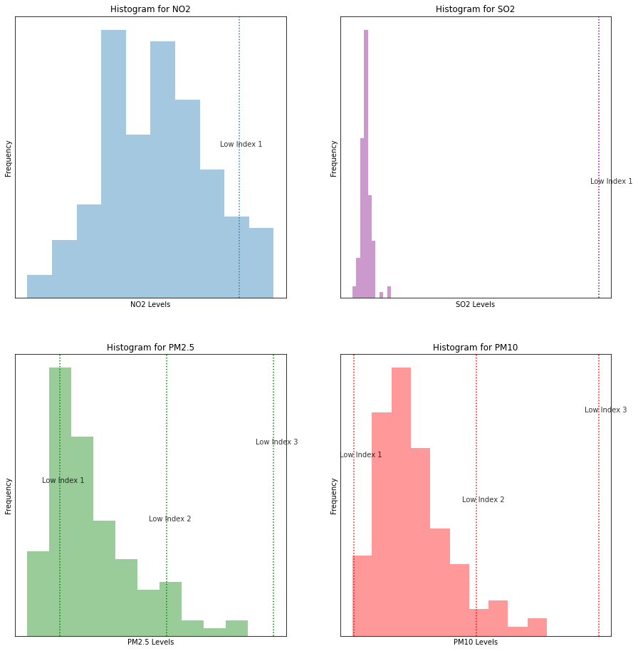

```python
fig, ((ax1, ax2), (ax3, ax4)) = plt.subplots(2, 2, figsize = (15,16))
ax1.set_yticks([]);ax2.set_yticks([]);ax3.set_yticks([]);ax4.set_yticks([])
ax1.set_xticks([]);ax2.set_xticks([]);ax3.set_xticks([]);ax4.set_xticks([])

AQI_month['Roadside NO2'].plot(kind='hist', ax=ax1, alpha =0.4)
ax1.set_xlabel("NO2 Levels")
ax1.set_title("Histogram for NO2")
ax1.axvline(float(boundaries['NO2_max'][boundaries['Index']==1]),linestyle=':')
ax1.text(float(boundaries['NO2_max'][boundaries['Index']==1])-3, 13, "Low Index 1", size = 10, alpha = 0.8)

AQI_month['Roadside SO2'].plot(kind='hist', ax=ax2, color='purple',alpha =0.4)
ax2.set_xlabel("SO2 Levels")
ax2.set_title("Histogram for SO2")
ax2.axvline(float(boundaries['SO2_max'][boundaries['Index']==1]),linestyle=':', color = 'purple')
ax2.text(float(boundaries['SO2_max'][boundaries['Index']==1])-3, 20, "Low Index 1", size = 10, alpha = 0.8)

AQI_month['Roadside PM2.5'].plot(kind='hist', ax=ax3, color='green',alpha =0.4)
ax3.set_xlabel("PM2.5 Levels")
ax3.set_title("Histogram for PM2.5")
ax3.axvline(float(boundaries['PM2.5_max'][boundaries['Index']==1]),linestyle=':', color = 'green')
ax3.text(float(boundaries['PM2.5_max'][boundaries['Index']==1])-2,20, "Low Index 1", size = 10, alpha = 0.8)
ax3.axvline(float(boundaries['PM2.5_max'][boundaries['Index']==2]),linestyle=':', color = 'green')
ax3.text(float(boundaries['PM2.5_max'][boundaries['Index']==2])-2,15, "Low Index 2", size = 10, alpha = 0.8)
ax3.axvline(float(boundaries['PM2.5_max'][boundaries['Index']==3]),linestyle=':', color = 'green')
ax3.text(float(boundaries['PM2.5_max'][boundaries['Index']==3])-2,25, "Low Index 3", size = 10, alpha = 0.8)

AQI_month['Roadside PM10'].plot(kind='hist', ax=ax4, color='red',alpha =0.4)
ax4.set_xlabel("PM10 Levels")
ax4.set_title("Histogram for PM10")
ax4.axvline(float(boundaries['PM10_max'][boundaries['Index']==1]),linestyle=':', color = 'red')
ax4.text(float(boundaries['PM10_max'][boundaries['Index']==1])-2,20, "Low Index 1", size = 10, alpha = 0.8)
ax4.axvline(float(boundaries['PM10_max'][boundaries['Index']==2]),linestyle=':', color = 'red')
ax4.text(float(boundaries['PM10_max'][boundaries['Index']==2])-2,15, "Low Index 2", size = 10, alpha = 0.8)
ax4.axvline(float(boundaries['PM10_max'][boundaries['Index']==3]),linestyle=':', color = 'red')
ax4.text(float(boundaries['PM10_max'][boundaries['Index']==3])-2,25, "Low Index 3", size = 10, alpha = 0.8);
```

#### Observation

- Levels of **NO2** in London are Low, they only go slightly above the the first Index Band
- Levels of **SO2** in London are VERY Low, they do no even cross the maximum levels for the first Index Band.
- Levels of **Particulate Matter** in London are also Low, but both **PM2.5** and **PM10** levels cross the second Index Band, so the concentrations are relatively higher compared to the other gases.

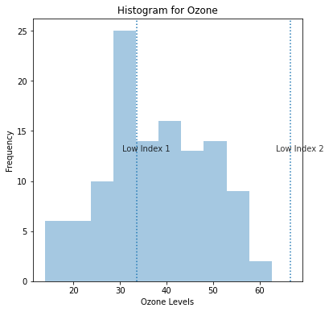

```python
fig, ax = plt.subplots(figsize=(6,6))
AQI_month['BG Ozone'].plot(kind='hist', ax=ax, alpha =0.4)
ax.set_xlabel("Ozone Levels")
ax.set_title("Histogram for Ozone")
ax.axvline(float(boundaries['Ozone_max'][boundaries['Index']==1]),linestyle=':')
ax.text(float(boundaries['Ozone_max'][boundaries['Index']==1])-3, 13, "Low Index 1", size = 10, alpha = 0.8)
ax.axvline(float(boundaries['Ozone_max'][boundaries['Index']==2]),linestyle=':')
ax.text(float(boundaries['Ozone_max'][boundaries['Index']==2])-3, 13, "Low Index 2", size = 10, alpha = 0.8)

plt.show()
```

#### Observation

Level of Ozone in London is also Low, and doesn't cross the second Index Band.

Overall, the pollution is in London is **Low**.

## Visualising the Pollution in various Boroughs

We have information about the emissions of the pollutant gases from the various Boroughs.

```python
display(boroughs.head(3))
display(air_boroughs.head(3))
```

|  | Borough | Latitude | Longitude | Area | Population |
| --- | --- | --- | --- | --- | --- |
| 0 | Barking and Dagenham | 51.5607 | 0.1557 | 13.93 | 212906 |
| 1 | Barnet | 51.6252 | -0.1517 | 33.49 | 395896 |
| 2 | Bexley | 51.4549 | 0.1505 | 23.38 | 248287 |

|  | Borough | NOx | PM2.5 | PM10 |
| --- | --- | --- | --- | --- |
| 0 | Barking and Dagenham | 909.442 | 104.478 | 235.321 |
| 1 | Barnet | 1831.89 | 188.619 | 469.191 |
| 2 | Bexley | 2238.08 | 143.658 | 304.201 |

```python
# Combining the dataframes by merging them on the basis of the Borough

pollution_boroughs = pd.merge(boroughs, air_boroughs, on="Borough", how='inner')
pollution_boroughs.head()
```

|  | Borough | Latitude | Longitude | Area | Population | NOx | PM2.5 | PM10 |
| --- | --- | --- | --- | --- | --- | --- | --- | --- |
| 0 | Barking and Dagenham | 51.5607 | 0.1557 | 13.93 | 212906 | 909.442 | 104.478 | 235.321 |
| 1 | Barnet | 51.6252 | -0.1517 | 33.49 | 395896 | 1831.89 | 188.619 | 469.191 |
| 2 | Bexley | 51.4549 | 0.1505 | 23.38 | 248287 | 2238.08 | 143.658 | 304.201 |
| 3 | Brent | 51.5588 | -0.2817 | 16.70 | 329771 | 1419.35 | 117.783 | 241.791 |
| 4 | Bromley | 51.4039 | 0.0198 | 57.97 | 332336 | 1285.05 | 160.323 | 361.063 |

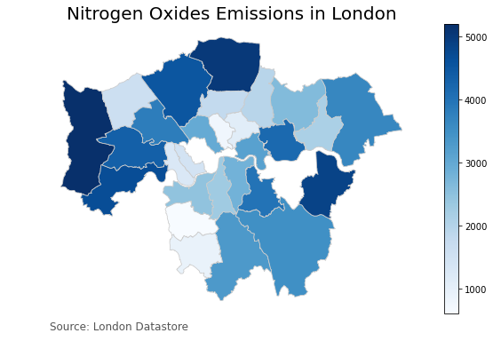

```python
# Using Geopandas to plot a basic map of London, we use the Shape File from London Datastore
fp = "data/ESRI/London_Borough_Excluding_MHW.shp"
map_df = gpd.read_file(fp)

# Join dataframes so that we can visualise the pollution levels in the various boroughs
merged = map_df.set_index('NAME').join(pollution_boroughs.set_index('Borough'))

fig, ax = plt.subplots(1, figsize=(10, 6))
merged.plot(column='NOx', cmap='Blues', linewidth=0.8, ax=ax, edgecolor='0.8')
ax.set_title('Nitrogen Oxides Emissions in London', fontdict={'fontsize': '20', 'fontweight' : '3'});
ax.axis('off')
ax.annotate('Source: London Datastore' ,xy=(0.1, .08),  xycoords='figure fraction', horizontalalignment='left', verticalalignment='top', fontsize=12, color='#555555')
# Create colorbar as a legend
sm = plt.cm.ScalarMappable(cmap='Blues', norm=plt.Normalize(vmin=600, vmax=5200))
# empty array for the data range
sm._A = []
# add the colorbar to the figure
cbar = fig.colorbar(sm)
```

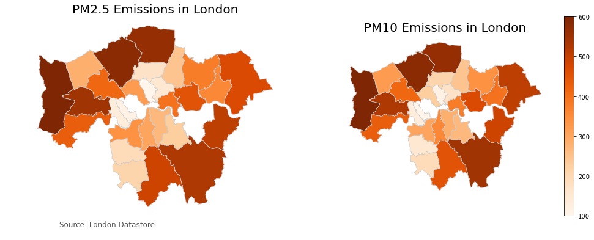

```python
fig, axes = plt.subplots(nrows =1,ncols = 2, figsize=(17, 6))

merged.plot(column='PM2.5', cmap='Oranges', linewidth=0.8, edgecolor='0.8', ax=axes[0])
axes[0].set_title('PM2.5 Emissions in London', fontdict={'fontsize': '20', 'fontweight' : '3'});
axes[0].axis('off')
axes[0].annotate('Source: London Datastore' ,xy=(0.1, .08),  xycoords='figure fraction', horizontalalignment='left', verticalalignment='top', fontsize=12, color='#555555')

merged.plot(column='PM10', cmap='Oranges', linewidth=0.8, edgecolor='0.8', ax=axes[1])
axes[1].set_title('PM10 Emissions in London', fontdict={'fontsize': '20', 'fontweight' : '3'});
axes[1].axis('off')

# Create colorbar as a legend
sm = plt.cm.ScalarMappable(cmap='Oranges', norm=plt.Normalize(vmin=100, vmax=600))
# empty array for the data range
sm._A = []
# add the colorbar to the figure
cbar = fig.colorbar(sm)
```

#### Observation

We would expect that Central London would have higher levels of pollution, however, our map shows us something different. This is because we have not taken into account the difference in area of the various boroughs. A borough with larger area will naturally have more pollution monitors, and will also be expected to have higher emissions of pollutants.

We can calculate the emissions per unit area of each borough and then plot the maps again to see if it is any different from these maps. Firstly, we check if our assumption actually holds or not, i.e, does increase in Area or Population actually increase in the pollutant levels?

We can plot a 3D graph of how **NOx** levels change with respect to change in Area or Population

```python
pollution_boroughs['NOx'] = pd.to_numeric(pollution_boroughs['NOx'])

fig = px.scatter_3d(pollution_boroughs, x='Area', y='Population', z='NOx', size='NOx',
                    width=800, height=600)
fig.update_layout(title = "Change in NOx Values for Increase in Area or Population")
fig.show()
```

[interactive chart not shown]

As we move the graph around, it is clear that higher NOx values occur for places with greater area and/or population. So our assumption was correct!

We already have the information about the emissions of various gases in each Borough, along with their Area and Population. We have seen that, those boroughs with larger area and larger population will have higher emissions. We focus on any one, say Area. We can find the emissions of each gas per unit area in each Borough.

```python
per_area = pollution_boroughs[['Borough','Latitude','Longitude']].copy()
per_area['NOx'] = pollution_boroughs['NOx']/pollution_boroughs['Area']
per_area['PM2.5'] = pollution_boroughs['PM2.5']/pollution_boroughs['Area']
per_area['PM10'] = pollution_boroughs['PM10']/pollution_boroughs['Area']

display(per_area.head(3))
```

|  | Borough | Latitude | Longitude | NOx | PM2.5 | PM10 |
| --- | --- | --- | --- | --- | --- | --- |
| 0 | Barking and Dagenham | 51.5607 | 0.1557 | 65.286586 | 7.50022 | 16.8931 |
| 1 | Barnet | 51.6252 | -0.1517 | 54.699658 | 5.6321 | 14.0099 |
| 2 | Bexley | 51.4549 | 0.1505 | 95.726467 | 6.14449 | 13.0111 |

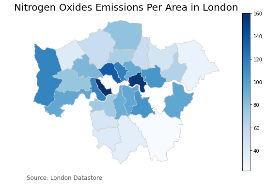

```python
# Join dataframes so that we can visualise the pollution levels in the various boroughs per area

merged = map_df.set_index('NAME').join(per_area.set_index('Borough'))

fig, ax = plt.subplots(1, figsize=(10, 6))
merged.plot(column='NOx', cmap='Blues', linewidth=0.8, ax=ax, edgecolor='0.8')
ax.set_title('Nitrogen Oxides Emissions Per Area in London', fontdict={'fontsize': '20', 'fontweight' : '3'});
ax.axis('off')
ax.annotate('Source: London Datastore' ,xy=(0.1, .08),  xycoords='figure fraction', horizontalalignment='left', verticalalignment='top', fontsize=12, color='#555555')
# Create colorbar as a legend
sm = plt.cm.ScalarMappable(cmap='Blues', norm=plt.Normalize(vmin=22, vmax=160))
# empty array for the data range
sm._A = []
# add the colorbar to the figure
cbar = fig.colorbar(sm)
```

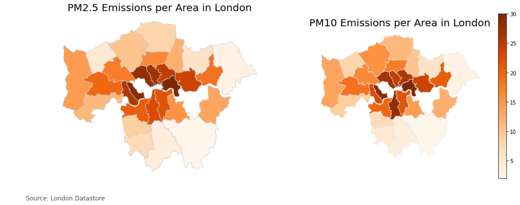

```python
fig, axes = plt.subplots(nrows =1,ncols = 2, figsize=(17, 6))

merged.plot(column='PM2.5', cmap='Oranges', linewidth=0.8, edgecolor='0.8', ax=axes[0])
axes[0].set_title('PM2.5 Emissions per Area in London', fontdict={'fontsize': '20', 'fontweight' : '3'});
axes[0].axis('off')
axes[0].annotate('Source: London Datastore' ,xy=(0.05, .05),  xycoords='figure fraction', horizontalalignment='left', verticalalignment='top', fontsize=12, color='#555555')

merged.plot(column='PM10', cmap='Oranges', linewidth=0.8, edgecolor='0.9', ax=axes[1])
axes[1].set_title('PM10 Emissions per Area in London', fontdict={'fontsize': '20', 'fontweight' : '3'});
axes[1].axis('off')

# Create colorbar as a legend
sm = plt.cm.ScalarMappable(cmap='Oranges', norm=plt.Normalize(vmin=2, vmax=30))
# empty array for the data range
sm._A = []
# add the colorbar to the figure
cbar = fig.colorbar(sm)
```

#### Observation

As expected, when we plot the pollutant emissions per unit area, we get the plot as we desired. The areas around Central London are darker, indicating that pollution emissions in Central London are much higher and they decrease as we move away from the center.

We, however, observe that the leftmost (West-wards) Borough of **Hillingdon** has higher pollution levels, especially for Nitrogen Oxides. We can take this Borough to be an outlier.

## Data Modelling

### Motivation

We want to know if we can group the various London Boroughs on the basis of their pollution emissions, that is, form clusters of boroughs that have similar levels of pollution emissions.

We already have a dataframe with pollution emissions per unit area, however, we would like to see how the pollution level is affected per person in each Borough as well. So we can find the pollution levels in each borough per person.

```python
# Finding pollution in each borough per person

per_person = pollution_boroughs[['Borough','Latitude','Longitude']].copy()
per_person['NOx'] = pollution_boroughs['NOx']/pollution_boroughs['Population']
per_person['PM2.5'] = pollution_boroughs['PM2.5']/pollution_boroughs['Population']
per_person['PM10'] = pollution_boroughs['PM10']/pollution_boroughs['Population']

display(per_person.head(3))
```

|  | Borough | Latitude | Longitude | NOx | PM2.5 | PM10 |
| --- | --- | --- | --- | --- | --- | --- |
| 0 | Barking and Dagenham | 51.5607 | 0.1557 | 0.004272 | 0.000490724 | 0.00110528 |
| 1 | Barnet | 51.6252 | -0.1517 | 0.004627 | 0.000476436 | 0.00118514 |
| 2 | Bexley | 51.4549 | 0.1505 | 0.009014 | 0.000578597 | 0.0012252 |

### Performing the Clustering

We use the K-means Clustering Algorithm to perform the clustering on the Boroughs. As the name suggests, the algorithm makes use of the “means” of the data to cluster them. Here “K” is just the number of clusters we want our data to be divided in. We have to choose the value of “K” ourselves, and there are ways in which can select the right “K” for our data.

*I had written in short article on Medium explaining the details about K-Means Clustering, which can be viewed [here](https://medium.com/swlh/basics-of-machine-learning-k-means-clustering-f5c16678aa4).*

```python
# Extracting the values
per_person_values = per_person[['NOx','PM2.5','PM10']].values
per_area_values = per_area[['NOx','PM2.5','PM10']].values

per_person_values[:3]
```

```
array([[0.004271566511304986, 0.0004907237984476164,
        0.001105280885978708],
       [0.004627203948724894, 0.0004764361682205707,
        0.0011851374094442593],
       [0.009014103805239582, 0.0005785968705765684,
        0.0012251975605658267]], dtype=object)
```

Our data may contain values that are measured in different units, especially of we wish to extend this code to contain more features. For this reason, we must standardize the data.

```python
scaler = StandardScaler()

per_person_scaled = scaler.fit_transform(per_person_values)
per_person_scaled[:3]
```

```
array([[-1.26234302e-01,  6.79748988e-01,  8.72069560e-01],
       [ 1.09026890e-03,  5.69322018e-01,  1.14635973e+00],
       [ 1.57167897e+00,  1.35890690e+00,  1.28395782e+00]])
```

```python
scaler = StandardScaler()

per_area_scaled = scaler.fit_transform(per_area_values)
per_area_scaled[:3]
```

```
array([[-0.46347248,  0.04404247,  0.29404156],
       [-0.75857181, -0.59298871, -0.2344508 ],
       [ 0.38500673, -0.41826539, -0.41751967]])
```

### Finding the right K value — The Elbow Method

The Elbow Method is one of the best ways to find out which value of ‘K’ will give us the most stable clusters. The Elbow Method is based on the concept that the best value of ‘K’ is the one where the ‘Within Sum of Squares’ (WSS) value is the least. The total WSS measures the compactness of the clustering and it should be as small as possible. The ‘Within Sum of squares’ or WSS value is defined as the sum of the squared distance between each member of the cluster and its centroid. Mathematically, this can be represented as:

[figure not shown]

Here the x values are the data points and the corresponding c values are the centroids to which these data points are assigned. We want a minimum WSS value for good clustering.

When we plot this value along with the corresponding value of ‘k’, we will observe a sharp decrease in the WSS value at some value of ‘k’. After this, the value will keep on decreasing, but very slowly. Clearly, the larger the k, the lesser the WSS value, but we don't want the least WSS value in that sense. We want a suitable value of ‘k’ such that our WSS value is low and if we take any value larger than this ‘k’, the change in WSS value is minimal.

*Note than, SSE (Sum of Squared Errors) can be also be used instead of WSS*

### Choosing the Appropriate Number of Clusters for Emission per Person

```python
kmeans_kwargs = {
     "init": "random",
     "n_init": 10,
     "max_iter": 300,
     "random_state": 10,
 }

 # A list holds the SSE values for each k
sse = []
for k in range(1, 11):
    kmeans = KMeans(n_clusters=k, **kmeans_kwargs)
    kmeans.fit(per_person_scaled)
    sse.append(kmeans.inertia_)
```

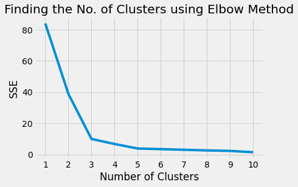

```python
plt.style.use("fivethirtyeight")
plt.plot(range(1, 11), sse)
plt.xticks(range(1, 11))
plt.xlabel("Number of Clusters")
plt.ylabel("SSE")
plt.title('Finding the No. of Clusters using Elbow Method')
plt.show()
```

We can clearly see the elbow point at **k = 3**. Therefore, choosing to cluster our boroughs into 3 groups based on the emissions per person would be ideal.

```python
# Fitting the model and getting the label points :

kmeans_person = KMeans(n_clusters=3, init = 'random', n_init = 10, max_iter = 300, random_state = 10)
kmeans_person.fit(per_person_scaled)
```

```
KMeans(init='random', n_clusters=3, random_state=10)
```

```python
person_labels = kmeans_person.labels_
person_labels
```

```
array([0, 0, 0, 2, 0, 2, 2, 0, 0, 2, 2, 2, 2, 0, 1, 0, 2, 2, 2, 2, 2, 2,
       2, 2, 2, 2, 2, 2], dtype=int32)
```

```python
# Creating a dataframe with these labels and Borough names, latitudes and Longitudes

grouped_per_person = per_person[['Borough','Latitude','Longitude']].copy()
grouped_per_person.insert(0, 'Labels', person_labels)

display(grouped_per_person.head())
```

|  | Labels | Borough | Latitude | Longitude |
| --- | --- | --- | --- | --- |
| 0 | 0 | Barking and Dagenham | 51.5607 | 0.1557 |
| 1 | 0 | Barnet | 51.6252 | -0.1517 |
| 2 | 0 | Bexley | 51.4549 | 0.1505 |
| 3 | 2 | Brent | 51.5588 | -0.2817 |
| 4 | 0 | Bromley | 51.4039 | 0.0198 |

```python
import matplotlib.colors as colors
london_latitude = 51.5072
london_longitude = -0.1276

# create map
map_clusters = folium.Map(location=[london_latitude, london_longitude], zoom_start=10)

# set color scheme for the clusters
x = np.arange(3)
ys = [i + x + (i*x)**2 for i in range(3)]
colors_array = cm.rainbow(np.linspace(0, 1, len(ys)))
rainbow = [colors.rgb2hex(i/2) for i in colors_array]

# add markers to the map
markers_colors = []
for lat, lon, poi, cluster in zip(grouped_per_person['Latitude'], grouped_per_person['Longitude'], grouped_per_person['Borough'], grouped_per_person['Labels']):
    label = folium.Popup(str(poi) + ' Cluster ' + str(cluster), parse_html=True)
    folium.CircleMarker(
        [lat, lon],
        radius=8,
        popup=label,
        color=rainbow[cluster-1],
        fill=True,
        fill_color=rainbow[cluster-1],
        fill_opacity=0.7).add_to(map_clusters)

map_clusters
```

Make this Notebook Trusted to load map: File -> Trust Notebook

[interactive chart not shown]

#### Observation

We can observe from the plot that most Boroughs in the center of London tend to fall in one cluster. This makes sense as Central London is much busier and commercialised than the outer parts of London.

As pointed out before, the leftmost Borough (**Hillingdon**) turns out to be the only one in Custer 1, so the K-Means Clustering algorithm has separated it out as it's own group.

```python
# Checking to confirm if it's Hillingdon which is the outlier

grouped_per_person[grouped_per_person['Labels']==1]
```

|  | Labels | Borough | Latitude | Longitude |
| --- | --- | --- | --- | --- |
| 14 | 1 | Hillingdon | 51.5441 | -0.476 |

### Choosing the Appropriate Number of Clusters for Emission per Area

```python
kmeans_kwargs = {
     "init": "random",
     "n_init": 10,
     "max_iter": 300,
     "random_state": 42,
 }

 # A list holds the SSE values for each k
sse = []
for k in range(1, 11):
    kmeans = KMeans(n_clusters=k, **kmeans_kwargs)
    kmeans.fit(per_area_scaled)
    sse.append(kmeans.inertia_)
```

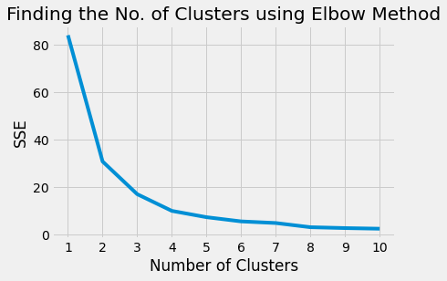

```python
plt.style.use("fivethirtyeight")
plt.plot(range(1, 11), sse)
plt.xticks(range(1, 11))
plt.xlabel("Number of Clusters")
plt.ylabel("SSE")
plt.title('Finding the No. of Clusters using Elbow Method')
plt.show()
```

Here, awe can choose eiether k = 2 or k = 3. Since we have around 28 Boroughs, it makes more sense to group them into 3 clusters rather than 2.

```python
# Fitting the model and getting the label points :

kmeans_area = KMeans(n_clusters=3, init = 'random', n_init = 10, max_iter = 300, random_state = 10)
kmeans_area.fit(per_area_scaled)
```

```
KMeans(init='random', n_clusters=3, random_state=10)
```

```python
area_labels = kmeans_area.labels_
area_labels
```

```
array([1, 1, 1, 1, 2, 0, 2, 1, 1, 0, 0, 1, 2, 2, 1, 1, 0, 0, 0, 1, 2, 0,
       2, 1, 2, 0, 2, 1], dtype=int32)
```

```python
# Creating a dataframe with these labels and Borough names, latitudes and Longitudes

grouped_per_area = per_area[['Borough','Latitude','Longitude']].copy()
grouped_per_area.insert(0, 'Labels', area_labels)

display(grouped_per_area.head())
```

|  | Labels | Borough | Latitude | Longitude |
| --- | --- | --- | --- | --- |
| 0 | 1 | Barking and Dagenham | 51.5607 | 0.1557 |
| 1 | 1 | Barnet | 51.6252 | -0.1517 |
| 2 | 1 | Bexley | 51.4549 | 0.1505 |
| 3 | 1 | Brent | 51.5588 | -0.2817 |
| 4 | 2 | Bromley | 51.4039 | 0.0198 |

```python
london_latitude = 51.5072
london_longitude = -0.1276

# create map
map_clusters = folium.Map(location=[london_latitude, london_longitude], zoom_start=10)

# set color scheme for the clusters
x = np.arange(3)
ys = [i + x + (i*x)**2 for i in range(3)]
colors_array = cm.rainbow(np.linspace(0, 1, len(ys)))
rainbow = [colors.rgb2hex(i/2) for i in colors_array]

# add markers to the map
markers_colors = []
for lat, lon, poi, cluster in zip(grouped_per_area['Latitude'], grouped_per_area['Longitude'], grouped_per_area['Borough'], grouped_per_area['Labels']):
    label = folium.Popup(str(poi) + ' Cluster ' + str(cluster), parse_html=True)
    folium.CircleMarker(
        [lat, lon],
        radius=8,
        popup=label,
        color=rainbow[cluster-1],
        fill=True,
        fill_color=rainbow[cluster-1],
        fill_opacity=0.7).add_to(map_clusters)

map_clusters
```

Make this Notebook Trusted to load map: File -> Trust Notebook

[interactive chart not shown]

#### Observation

Similar to when we grouped the Boroughs on the basis of emissions per person, here as well, the boroughs closer to central London all get grouped together.

Here, **Hillingdon** is not separated out.

## Conclusion \& Results

### The various pollutants in the air that are monitored to calculate the Air Quality Index

- Throughout our analysis, we come across 4 different kinds of pollutant gases: Nitrogen Oxides (NO and NO2), Ozone, Sulphur Dioxide, and Particulate Matter (PM2.5 and PM10)
- Concentrations of some of these pollutants are not independent. NO oxidises with Ozone to form NO2, therefore the concentration of NO and NO2 goes hand in hand. While increase in concentration of Nitrogen Oxides means a decrease in concentration of Ozone. This point is backed by our analysis.

### Comparison between "Roadside" and "Background" Monitors

- Roadside monitors report higher pollutant levels for pollutants like Nitogen Oxides, Particulate Matter and Sulphur Dioxide. This is obvious as these sites are near busy roads or a major source of pollution (like construction sites or petrol stations)
- Ozone is reported to be higher by the Background Monitors. This is because these areas usually have very low levels of Nitrogen Oxides, which is known to destroy Ozone in the atmosphere.
- There is no significant difference between the trend of pollution levels reported by Roadside and Background Monitors during different times of the day. When Pollution reported by Roadside monitor is high (like during peak office hours), then so is the pollution reported by Background monitors.

### Amount of pollutants in the air at different times of the day, month, and year

- Levels of Nitrogen Oxides were much higher during Winter Months, compared to Summer Months
- The concentrations of Particulate Matter tends of peak during the February - April period
- Ozone concentration is highest during the Summer Months
- The concentration of SO2 remains quite stable throughout the year.
- Both in Winter Months and Summer Months, the pollution levels peaks at 6 am (early morning) and then late evening. This can be because this is the time when people start to go to work and majority of public transport vehicles begin operating (Office Hours).

### The emissions of the various pollutants from the London Boroughs

- Our analysis showed that the overall pollution level in London is Low. None of the major pollutants are present in the air in high concentrations.
- When we compared the pollutant emissions in the various boroughs, we found no particular trend that would suggest that the pollution varies by geography. However, we did notice that boroughs with larger areas had higher pollutant emissions. This pointed us towards looking at the emissions per unit area so that we can examine the boroughs fairly
- When we plotted the maps based on the emissions per unit area, it is clear that boroughs in central London have much higher emissions.

### How does the Air Quality Index vary over a period of 10 years ?

- There is sharp decrease in Nitrogen Oxides from the year 2016 due to the decrease in dirty vehicles in the city and lower usage of coal
- Particulate Matter and Sulphur Dioxide have also decreased in concentration of the years due to the same reasons.
- Level of Ozone in the air is not directly impacted by human activities. It depends largely on the presence of other gases in the air and the location of the monitoring site. Therefore, its concentration has fluctuated.

### Trends in Air Quality Index depending on the time of the day, month and year ?

As outlined in our analysis:-

- Since Nitrogen Oxides are produced when fuel is burnt, the increase in burning of fuels for the purpose of heating in the winter months makes it clear why the concentration peaks during these months. Also, in winter, when the ground in cold, most emissions are trapped near to the ground and further increase the concentration of these gases in the air.
- According to the UK Government Website, the increase in concentration of Particulate Matter during the February - April time can be attributed to the increase in burning of wood and coal by households in stoves and open fires. This coupled with the wind patterns leads to this peak in concentration.
- Ozone pollution worsens in the summer months as a lot of the compounds that react to form Ozone, do so in the presence of sunlight, so longer days with bright sunlight act as catalysts for these reactions. Moreover, the decrease in Nitrogen Oxides in the air also contributes to the increase in Ozone, as NO reacts with Ozone (destroying it) to form further Nitrogen Oxides.
- The variation in the pollution levels during the Winter Months has been more when compared over the period of 10 years. The concentration of gases like Nitrogen Oxides, SO2 and Particulate Matter in the month of January are very high. However, they decrease as we progress into the summer months, but then again increase as we move towards September and the later Winter Months. The trend for Ozone is exactly the opposite.

### Which London Boroughs have the most emissions for the pollutants?

From plotting maps based on pollution emissions per unit area, and modelling the data into groups based on the emissions per unit area and per unit person, it is clear that the boroughs in in and near Zone 1 of London (Central London) have the most emissions of pollutants. These include boroughs like Camden, Kensington, Hackney, Tower Hamlets, Islington and Lambeth.

### Can we group the Boroughs based on their level of pollutant emissions?

- Yes, through our analysis, we found that we can group the boroughs on the basis of 2 factors - Pollution emissions per person and Pollution emissions per unit area.
- When grouping boroughs according to pollution emissions per person, we get 2 proper clusters and the outlier(s) are separated out.
- When grouping the boroughs according to pollution per unit area, we get 3 proper clusters.
- The clustering suggests that the boroughs in the centre can approximately be grouped together, and boroughs on the boundaries can be groups together. This makes sense as our analysis showed that pollution levels are much higher in the centre.